# Supplementary code

Improving risk stratification for patients with type 2 myocardial infarction

Karla Monterrubio-Gomez PhD, Caelan Taggart MD, Catalina A. Vallejos PhD, Andrew R. Chapman MD PhD

```r
library(dplyr)
library(rms)
library(regplot)
library(qwraps2)
library(knitr)
library(kableExtra)
library(mice)
library(naniar)
library(VIM)
library(gtsummary)
library(tidyverse)
library(prodlim)
library(survminer)
library(pROC)
library(gridGraphics)
library(grid)
library(polspline)
library(ggROC)
library(forestplot)
library(gt)
library(ggplot2)
library(PRROC)
library(pec)
options(qwraps2_markup = "markdown")
```

# 1 Data

The dataset here used comes from High-STEACS (High Sensitivity Troponin in the Evaluation of patients with suspected Acute Coronary Syndrome) trial.

## 1.1 Pre-processing

We load available data and filter type 2 MI events only. The analysed dataset contains 1121 patients.

```r
data.path   <- file.path("//farr-fs1/Study Data/LOT-16-001/Research",
                          "High-STEACS/HS006_BHF-Turing/KarlaMonterrubio")
data        <- readRDS(file.path(data.path, "Data_analysis.Rds"))

ct.master   <- readRDS(file.path(data.path,"TypeII_MI/ct.master.hs.data.rds")) #ct.master contains variables not included in data, and which will be used for the analysis
names(ct.master)[names(ct.master)=="patientid"] <- "PatientId"
ct.master.tomerge <- ct.master[, c("PatientId","type1ortype4bmi1", "type1ortype4bmidate",
                                     "mechanism", "arrival_date", "cardiovasculardeathdate")]
data_TypeII <- merge(data,ct.master.tomerge , by="PatientId")
data_TypeII <- subset(data_TypeII, udmi4=="Type 2 MI")
```

Now, let’s select the clinical covariates that we will be using.

```r
covariates <- c("PatientId", "AGE_ON_ARRIVAL", "SEX_CODE_LOC", "PeakHSTn",
                "haemoglobinvalue","PrevHFHospitalisation", "PrevCD",
                "PrevDiabetes", "PrevIHD",  "MyocardialIschemia",
                "prim_out", "outcomedate_prim", "non_cardio_death", "days.to.mace.death.followup",
                "DaysFromIndexAdmission", "arrival_date", "type1ortype4bmidate",
                "cardiovasculardeathdate", "CreatinineValue", "PrevMI","SystolicBP", "HeartRate")
data_TypeII_clinical <- data_TypeII[ , covariates]
colnames(data_TypeII_clinical) <- c("PatientID","Age","Sex","PeakTroponin",
                                    "Haemoglobin","PrevHFHospitalisation","PrevCD",
                                   "PrevDiabetes", "PrevIHD", "MyocardialIschemia",
                                   "secondary_outcome","outcomedate_secout",
                                    "non_cardio_death", "days.to.mace.death.followup",
                                   "DaysFromIndexAdmission", "arrival_date",
                                   "type1ortype4bmidate", "cardiovasculardeathdate", "CreatinineValue",
                                   "PrevMI","SystolicBP", "HeartRate")
```

We will compute eGFR based on MDRD equation using available covariates: creatinine, age and sex.

```r
data_TypeII_clinical$eGFR<- round(186*((data_TypeII_clinical$CreatinineValue/88.42)^-1.154)*
                                              data_TypeII_clinical$Age^-0.203*
                                              ifelse(data_TypeII_clinical$Sex=="F",0.742,1 ))

#Mark eGFR as NA when CreatinineValue is either NA or 0.
pos.creatzero <- which(data_TypeII_clinical$CreatinineValue==0)
data_TypeII_clinical$eGFR[pos.creatzero] <- NA
```

We employ Haemoglobin and Sex to define a new covariate of interest: Anaemia. Following the defition of the WHO, this is derived as:

- For male: Haemoglobin < 130 then Anaemia = Yes; otherwise Anaemia = No
- For female: Haemoglobin < 120 then Anaemia = Yes; otherwise Anaemia = No

```r
 data_TypeII_clinical$Anaemia <- NA
 data_TypeII_clinical$Anaemia <- ifelse(data_TypeII_clinical$Sex=="F",
                                ifelse(data_TypeII_clinical$Haemoglobin<120, "Yes", "No"),
                                ifelse(data_TypeII_clinical$Haemoglobin<130, "Yes", "No"))

 data_TypeII_clinical$Anaemia <- as.factor(data_TypeII_clinical$Anaemia)
 data_TypeII_clinical$Anaemia <- relevel(data_TypeII_clinical$Anaemia, ref= "No")
```

Now, we derive time to event variables for each of the events of interest:

- Primary outcome: MI or all cause death at 365 days
- Secondary outcome: MI or cardiovascular death at 365 days

```r
#compute the days to event for MI
data_TypeII_clinical$MI_days <- as.numeric(round(difftime(data_TypeII_clinical$type1ortype4bmidate, data_TypeII_clinical$arrival_date, units = "days")))
data_TypeII_clinical$MI_days[is.na(data_TypeII_clinical$MI_days)==TRUE] <- 365

#time to cardiovascular death
data_TypeII_clinical$Cardio_days <- as.numeric(round(difftime(data_TypeII_clinical$cardiovasculardeathdate, data_TypeII_clinical$arrival_date, units = "days")))
data_TypeII_clinical$Cardio_days[is.na(data_TypeII_clinical$Cardio_days)==TRUE] <- 365

#Time for secondary outcome. Note, we are rounding numerically.
data_TypeII_clinical$Secout_days <- pmin(data_TypeII_clinical$MI_days, data_TypeII_clinical$Cardio_days)


#Status=1 secondary out, status=2 non_cardio death, status =0 censored.
data_TypeII_clinical$status <- ifelse(data_TypeII_clinical$secondary_outcome==1,1,
                               ifelse(data_TypeII_clinical$non_cardio_death==1,2,0))

#time for Competing events
data_TypeII_clinical$timetoevent_cr <- data_TypeII_clinical$Secout_days
pos_CR <- which(data_TypeII_clinical$status == 2)
data_TypeII_clinical$timetoevent_cr[pos_CR] <- data_TypeII_clinical$DaysFromIndexAdmission[pos_CR]


#days to all-cause death or MI
data_TypeII_clinical$days_MIorALLCAUSE <- pmin(data_TypeII_clinical$MI_days,data_TypeII_clinical$DaysFromIndexAdmission)

#indicator for all-cause death or MI
data_TypeII_clinical$MIorAllcausedeath <- rep(0, nrow(data_TypeII_clinical))
pos_MI <- which(is.na(data_TypeII_clinical$type1ortype4bmidate)==FALSE)
data_TypeII_clinical$MIorAllcausedeath[pos_MI] <- 1
pos_deaths <- which(data_TypeII_clinical$DaysFromIndexAdmission<365)
data_TypeII_clinical$MIorAllcausedeath[pos_deaths] <- 1
```

Now, we mark as factor all discrete variables. In addition, we change 1 and 2 for Yes and No to be more explicit. Also, we set No as reference for all binary varibles.

```r
data_TypeII_clinical$PrevHFHospitalisation <- as.factor(data_TypeII_clinical$PrevHFHospitalisation)
data_TypeII_clinical$PrevDiabetes <- as.factor(data_TypeII_clinical$PrevDiabetes)
data_TypeII_clinical$PrevIHD <- as.factor(data_TypeII_clinical$PrevIHD)
data_TypeII_clinical$PrevMI <- as.factor(data_TypeII_clinical$PrevMI)
data_TypeII_clinical$PrevCD <- as.factor(data_TypeII_clinical$PrevCD)
data_TypeII_clinical$MyocardialIschemia <- as.factor(data_TypeII_clinical$MyocardialIschemia)
data_TypeII_clinical$Sex <- as.factor(data_TypeII_clinical$Sex)

data_TypeII_clinical$PrevDiabetes <- recode_factor(data_TypeII_clinical$PrevDiabetes, `1`="Yes", '2'="No")
data_TypeII_clinical$PrevIHD  <- recode_factor(data_TypeII_clinical$PrevIHD,`1`="Yes", '2'="No")
data_TypeII_clinical$PrevMI <- recode_factor(data_TypeII_clinical$PrevMI, `1`="Yes", '2'="No")
data_TypeII_clinical$PrevHFHospitalisation  <- recode_factor(data_TypeII_clinical$PrevHFHospitalisation,`1`="Yes", '2'="No")
data_TypeII_clinical$PrevCD <- recode_factor(data_TypeII_clinical$PrevCD, `1`="Yes", '2'="No")
data_TypeII_clinical$PrevIHD <- relevel(data_TypeII_clinical$PrevIHD, ref="No")
data_TypeII_clinical$PrevDiabetes <- relevel(data_TypeII_clinical$PrevDiabetes, ref="No")
data_TypeII_clinical$PrevHFHospitalisation <- relevel(data_TypeII_clinical$PrevHFHospitalisation, ref="No")
data_TypeII_clinical$PrevCD <- relevel(data_TypeII_clinical$PrevCD, ref = "No")
data_TypeII_clinical$MyocardialIschemia <- relevel(data_TypeII_clinical$MyocardialIschemia, ref= "No")
data_TypeII_clinical$Sex <- relevel(data_TypeII_clinical$Sex, ref = "M")
data_TypeII_clinical$PrevMI <- relevel(data_TypeII_clinical$PrevMI, ref = "No")
```

## 1.2 Baseline characteristics

Summary table of the baseline characteristics of our derivation cohort stratified by primary outcome.

```r
data_TypeII_clinical$mygroup <- factor(data_TypeII_clinical$MIorAllcausedeath,
                                       levels = c(1,0),
                                       labels = c("Primary Outcome", "Censored"))

tab1_baselineC <- data_TypeII_clinical%>%
                        select( Age, Sex, PrevMI, PrevIHD, PrevCD, PrevDiabetes,
                                PrevHFHospitalisation, Anaemia, MyocardialIschemia,
                                HeartRate, SystolicBP, Haemoglobin,eGFR, PeakTroponin, mygroup) %>%
                        tbl_summary( by = mygroup,
                                     label = list(Age ~"Age (years)",
                                                  Sex ~ "Male",
                                                  PrevMI ~ "Myocardial infarction",
                                                  PrevIHD ~  "Ischaemic heart disease",
                                                  PrevCD ~"Cerebrovascular disease",
                                                  PrevDiabetes ~ "Diabetes Mellitus",
                                                  PrevHFHospitalisation ~ "Heart failure hospitalisation",
                                                  Anaemia ~ "Anaemia",
                                                  MyocardialIschemia ~ "Myocardial Ischaemia",
                                                  HeartRate ~ "Heart rate (b.p.m)",
                                                  SystolicBP ~ "Systolic blood pressure (mmHg)",
                                                  Haemoglobin ~ "Haemoglobin",
                                                  eGFR ~ "eGFR (mL/min)",
                                                  PeakTroponin ~ "Peak hs-cTnl"),
                                    statistic = list(Age ~ "{mean} ({sd})",
                                                     Sex ~"{n} ({p}%)",
                                                     PrevMI ~ "{n} ({p}%)",
                                                     PrevIHD ~ "{n} ({p}%)",
                                                     PrevCD ~ "{n} ({p}%)",
                                                     PrevDiabetes ~ "{n} ({p}%)",
                                                    PrevHFHospitalisation ~ "{n} ({p}%)",
                                                    Anaemia ~ "{n} ({p}%)",
                                                    MyocardialIschemia ~ "{n} ({p}%)",
                                                    HeartRate ~ "{mean} ({sd})",
                                                    SystolicBP ~ "{mean} ({sd})",
                                                    Haemoglobin ~ "{mean} ({sd})",
                                                    eGFR ~ "{mean} ({sd})",
                                                    PeakTroponin ~"{median} [{p25}, {p75}]"),
                                  missing_text = "(Missing)",
                                  value = Sex~"M") %>%
      add_overall() %>%
      add_n() %>%
      modify_header(label ~ "") %>%
      modify_spanning_header(all_stat_cols() ~ "**Derivation cohort**") %>%
      as_gt() %>%
      gt::tab_row_group(label = "Haematology and clinical chemistry", rows = 16:20) %>%
      gt::tab_row_group(label = "Physiological parameters", rows=12:15) %>%
      gt::tab_row_group(label = "Electrocardiogram", rows = 10:11) %>%
      gt::tab_row_group(label = "Past medical history", rows = 3:9)%>%
      gt::tab_row_group(label = "Demographics", rows = 1:2)

tab1_baselineC
```

|  | **N** | **Derivation cohort** **Overall**, N = 1,121<sup>1</sup> | **Derivation cohort** **Primary Outcome**, N = 297<sup>1</sup> | **Derivation cohort** **Censored**, N = 824<sup>1</sup> |
| --- | --- | --- | --- | --- |
| Demographics |  |  |  |  |
| Age (years) | 1,121 | 74 (14) | 80 (11) | 72 (14) |
| Male | 1,121 | 501 (45%) | 130 (44%) | 371 (45%) |
| Past medical history |  |  |  |  |
| Myocardial infarction | 1,121 | 163 (15%) | 68 (23%) | 95 (12%) |
| Ischaemic heart disease | 1,121 | 454 (40%) | 159 (54%) | 295 (36%) |
| Cerebrovascular disease | 1,121 | 135 (12%) | 53 (18%) | 82 (10.0%) |
| Diabetes Mellitus | 1,121 | 147 (13%) | 60 (20%) | 87 (11%) |
| Heart failure hospitalisation | 1,121 | 292 (26%) | 121 (41%) | 171 (21%) |
| Anaemia | 1,095 | 398 (36%) | 156 (54%) | 242 (30%) |
| (Missing) |  | 26 | 6 | 20 |
| Electrocardiogram |  |  |  |  |
| Myocardial Ischaemia | 1,033 | 383 (37%) | 113 (42%) | 270 (35%) |
| (Missing) |  | 88 | 31 | 57 |
| Physiological parameters |  |  |  |  |
| Heart rate (b.p.m) | 888 | 105 (35) | 99 (30) | 107 (37) |
| (Missing) |  | 233 | 62 | 171 |
| Systolic blood pressure (mmHg) | 701 | 132 (30) | 130 (30) | 133 (30) |
| (Missing) |  | 420 | 116 | 304 |
| Haematology and clinical chemistry |  |  |  |  |
| Haemoglobin | 1,095 | 126 (29) | 117 (29) | 129 (29) |
| (Missing) |  | 26 | 6 | 20 |
| eGFR (mL/min) | 1,099 | 64 (25) | 56 (27) | 66 (24) |
| (Missing) |  | 22 | 5 | 17 |
| Peak hs-cTnl | 1,121 | 125 [48, 604] | 148 [60, 822] | 112 [45, 522] |

<sup>*1*</sup> Mean (SD); n (%); Median [IQR]

## 1.3 Missing values

This section provides an analysis of missing values per covariate of interest. First, we produce plots that summarize such information.

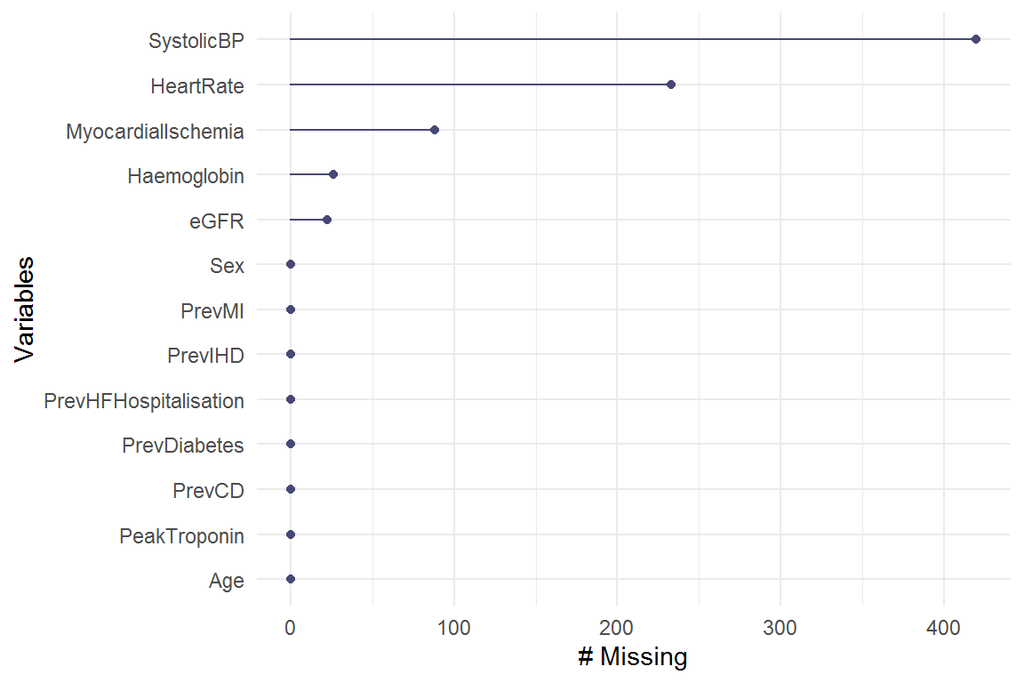

```r
covariates_clinical <- c("Age", "Sex", "PrevMI", "PrevIHD","PrevCD",
                         "PrevDiabetes","PrevHFHospitalisation","MyocardialIschemia",
                         "SystolicBP", "HeartRate","Haemoglobin", "eGFR", "PeakTroponin")

gg_miss_var(data_TypeII_clinical[, covariates_clinical])
```

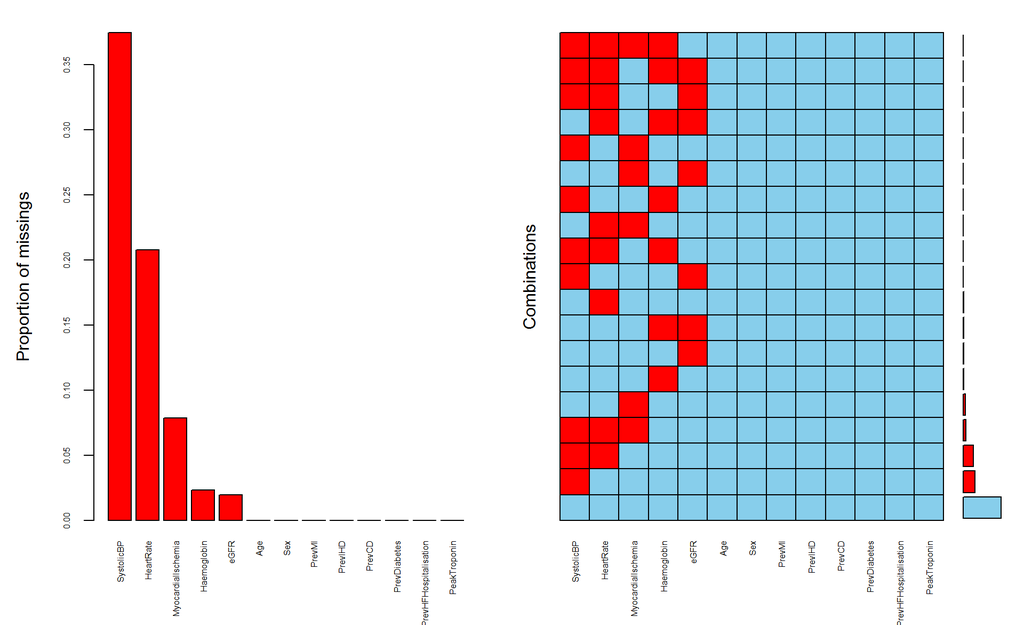

```
##
##  Variables sorted by number of missings:
##               Variable      Count
##             SystolicBP 0.37466548
##              HeartRate 0.20785013
##     MyocardialIschemia 0.07850134
##            Haemoglobin 0.02319358
##                   eGFR 0.01962533
##                    Age 0.00000000
##                    Sex 0.00000000
##                 PrevMI 0.00000000
##                PrevIHD 0.00000000
##                 PrevCD 0.00000000
##           PrevDiabetes 0.00000000
##  PrevHFHospitalisation 0.00000000
##           PeakTroponin 0.00000000
```

```r
missingplot <- summary(aggr(data_TypeII_clinical[,covariates_clinical],
                       cex.lab =1, cex.axis =.5, sortVar = T, digits = 2,
                       combined = FALSE))$percent
```

We will not consider SystolicBP in our model because the proportion of missing values is very high (37.5%). However, for the other covariates that have missing values we will use imputation.

In order to impute missing values, we use mice R package with predicting mean matching (pmm). This method works for both continuous and discrete covariates, ensuring that the imputed values have a similar distribution as those observed, and as such it won’t produce imputed values outside the range of the observed data. In addition, pmm is known for being robust to transformations (eg. log).

```r
set.seed(40)
cov_impute <- c("Age", "Sex","PeakTroponin", "PrevHFHospitalisation", "Haemoglobin","PrevDiabetes",
                "PrevIHD","PrevCD","MyocardialIschemia","eGFR", "HeartRate")

imputed_data <- mice(data_TypeII_clinical[ ,cov_impute], m = 5, maxit = 50, method = "pmm",seed = 500)

data_TypeII_imputed1 <- complete(imputed_data,2)
data_typeII_imputed <- data.frame(cbind(data_TypeII_clinical$PatientID,
                                        data_TypeII_imputed1,
                                        data_TypeII_clinical[, c("Secout_days", "secondary_outcome",
                                                                 "status","timetoevent_cr",
                                                                 "days_MIorALLCAUSE",
                                                                 "MIorAllcausedeath" )]))
```

Once, we have imputed the dataset, we employ Haemoglobin and Sex to define Anaemia. This is defined as:

```r
 data_typeII_imputed$Anaemia <- NA
 data_typeII_imputed$Anaemia <- ifelse(data_typeII_imputed$Sex=="F",
                                ifelse(data_typeII_imputed$Haemoglobin<120, "Yes", "No"),
                                ifelse(data_typeII_imputed$Haemoglobin<130, "Yes", "No"))

 data_typeII_imputed$Anaemia <- as.factor(data_typeII_imputed$Anaemia)
 data_typeII_imputed$Anaemia <- relevel(data_typeII_imputed$Anaemia, ref = "No")

data_TypeII_imputed <- data_typeII_imputed
colnames(data_TypeII_imputed)[1]<- "PatientId"
```

We produce summary statistics of the selected covariates for modelling after imputation:

```r
tab2 <- data_TypeII_imputed %>% select( Age, PrevIHD, PrevDiabetes, Anaemia,
                                PrevHFHospitalisation, eGFR, PeakTroponin,
                                MyocardialIschemia, HeartRate) %>%
                        tbl_summary(label= list(Age ~ "Age (years)",
                                                PrevIHD ~ "Ischaemic heart disease",
                                                PrevDiabetes ~ "Diabetes Mellitus",
                                                PrevHFHospitalisation ~ "Heart failure hospitalisation",
                                                eGFR ~ "eGFR (mL/min)",
                                                PeakTroponin ~ "Peak hs-cTnl",
                                                MyocardialIschemia ~ "Myocardial Ischaemia",
                                                HeartRate ~ "Heart rate (b.p.m)"),
                                   statistic = list(Age ~ "{mean} ({sd})",
                                                    PrevIHD ~ "{n} ({p}%)",
                                                    PrevDiabetes~ "{n} ({p}%)",
                                                    Anaemia~"{n} ({p}%)",
                                                    PrevHFHospitalisation ~ "{n} ({p}%)",
                                                    eGFR ~ "{mean} ({sd})",
                                                    PeakTroponin ~ "{median} [{p25}, {p75}]",
                                                    MyocardialIschemia ~ "{n} ({p}%)",
                                                    HeartRate ~ "{mean} ({sd})")) %>%
           modify_header(label = "", update = all_stat_cols(FALSE) ~ "n={n}") %>%
           as_gt() %>%
          gt::tab_source_note(gt::md(
            "*Data was missing for the following variables (n, %): Heart rate (233, 20.8%), Myocardial
            Ischaemia (88, 7.9%), Haemoglobin (26, 2.3%) required for Anaemia, and eGFR (22, 2%).*"))

tab2
```

|  | **N = 1,121**<sup>1</sup> |
| --- | --- |
| Age (years) | 74 (14) |
| Ischaemic heart disease | 454 (40%) |
| Diabetes Mellitus | 147 (13%) |
| Anaemia | 408 (36%) |
| Heart failure hospitalisation | 292 (26%) |
| eGFR (mL/min) | 64 (25) |
| Peak hs-cTnl | 125 [48, 604] |
| Myocardial Ischaemia | 418 (37%) |
| Heart rate (b.p.m) | 105 (35) |

*Data was missing for the following variables (n, %): Heart rate (233, 20.8%), Myocardial Ischaemia (88, 7.9%), Haemoglobin (26, 2.3%) required for Anaemia, and eGFR (22, 2%).*  
<sup>*1*</sup> Mean (SD); n (%); Median [IQR]

# 2 Primary outcome CPH model

## 2.1 Univariate analysis

In the following, we investigate univariate effects on the primary outcome.

First, in order to better account for linearity, we log transformed Troponin.

```r
data_TypeII_imputed_reduced$logTroponin <- log(data_TypeII_imputed_reduced$PeakTroponin)
data_TypeII_imputed_reduced <- as.data.frame(data_TypeII_imputed_reduced)
```

We now fit univariate Cox PH models for all covariates of interest. As a result of an initial residual analysis (not shown), we remove two strong outliers, and consequently the number of subjects analysed here is 1119.

```r
d = datadist(data_TypeII_clinical_reduced)
options(datadist = "d")

Cox_primout_sex <- cph(Surv(days_MIorALLCAUSE, MIorAllcausedeath)~ Sex,
                      data = data_TypeII_clinical_reduced,
                    x = TRUE, y = TRUE, surv = TRUE, model = TRUE,
                    time.inc = 365)

Cox_primout_prevCD <- cph(Surv(days_MIorALLCAUSE, MIorAllcausedeath)~ PrevCD,
                      data = data_TypeII_clinical_reduced,
                    x = TRUE, y = TRUE, surv = TRUE, model = TRUE,
                    time.inc = 365)

Cox_primout_MI <- cph(Surv(days_MIorALLCAUSE, MIorAllcausedeath)~ PrevMI,
                      data = data_TypeII_clinical_reduced,
                    x = TRUE, y = TRUE, surv = TRUE, model = TRUE,
                    time.inc = 365)



d = datadist(data_TypeII_imputed_reduced)
options(datadist = "d")

Cox_primout_age <- cph(Surv(days_MIorALLCAUSE, MIorAllcausedeath)~ Age,
                      data = data_TypeII_imputed_reduced,
                    x = TRUE, y = TRUE, surv = TRUE, model = TRUE,
                    time.inc = 365)



Cox_primout_egfr <- cph(Surv(days_MIorALLCAUSE, MIorAllcausedeath)~ eGFR,
                      data = data_TypeII_imputed_reduced,
                    x = TRUE, y = TRUE, surv = TRUE, model = TRUE,
                    time.inc = 365)


Cox_primout_ltrop <- cph(Surv(days_MIorALLCAUSE, MIorAllcausedeath)~  logTroponin,
                      data = data_TypeII_imputed_reduced,
                    x = TRUE, y = TRUE, surv = TRUE, model = TRUE,
                    time.inc = 365)



 Cox_primout_Anaemia <- cph(Surv(days_MIorALLCAUSE, MIorAllcausedeath)~  Anaemia,
                      data = data_TypeII_imputed_reduced,
                    x = TRUE, y = TRUE, surv = TRUE, model = TRUE,
                    time.inc = 365)


 Cox_primout_myocardialI <- cph(Surv(days_MIorALLCAUSE, MIorAllcausedeath)~  MyocardialIschemia,
                      data = data_TypeII_imputed_reduced,
                    x = TRUE, y = TRUE, surv = TRUE, model = TRUE,
                    time.inc = 365)


 Cox_primout_prevHFH <- cph(Surv(days_MIorALLCAUSE, MIorAllcausedeath)~ PrevHFHospitalisation,
                      data = data_TypeII_imputed_reduced,
                    x = TRUE, y = TRUE, surv = TRUE, model = TRUE,
                    time.inc = 365)


Cox_primout_prevDiabetes <- cph(Surv(days_MIorALLCAUSE, MIorAllcausedeath)~  PrevDiabetes,
                      data = data_TypeII_imputed_reduced,
                    x = TRUE, y = TRUE, surv = TRUE, model = TRUE,
                    time.inc = 365)


 Cox_primout_prevIHD <- cph(Surv(days_MIorALLCAUSE, MIorAllcausedeath)~  PrevIHD,
                      data = data_TypeII_imputed_reduced,
                    x = TRUE, y = TRUE, surv = TRUE, model = TRUE,
                    time.inc = 365)


 Cox_primout_HR <- cph(Surv(days_MIorALLCAUSE, MIorAllcausedeath)~  HeartRate,
                      data = data_TypeII_imputed_reduced,
                    x = TRUE, y = TRUE, surv = TRUE, model = TRUE,
                    time.inc = 365)
```

A summary table of the estimated HR along with 95% CI for each of the univariate models is provided.

```r
table_univariate<-(cbind("Sex - M:F",round(summary(Cox_primout_sex)[2,4],2),paste(round(summary(
  Cox_primout_sex)[2,6],2),",", round(summary(
Cox_primout_sex)[2,7],2))))


table_univariate<-data.frame(rbind(table_univariate,
      c("PrevMI - Yes:No",round(summary(Cox_primout_MI)[2,4],2),paste(round(summary(
  Cox_primout_MI)[2,6],2),",", round(summary(
Cox_primout_MI)[2,7],2))),
c("PrevCD - Yes:No",round(summary(Cox_primout_prevCD)[2,4],2),paste(round(summary(
  Cox_primout_prevCD)[2,6],2),",", round(summary(
Cox_primout_prevCD)[2,7],2))),
c("Age - 67:84",round(summary(Cox_primout_age)[2,4],2),paste(round(summary(
  Cox_primout_age)[2,6],2),",", round(summary(
Cox_primout_age)[2,7],2))),
c("eGFR - 45:81",round(summary(Cox_primout_egfr)[2,4],2),paste(round(summary(
  Cox_primout_egfr)[2,6],2),",", round(summary(
Cox_primout_egfr)[2,7],2))),
c("logTroponin - 3.87:6.40",round(summary(Cox_primout_ltrop)[2,4],2),paste(round(summary(
  Cox_primout_ltrop)[2,6],2),",", round(summary(
Cox_primout_ltrop)[2,7],2))),
c("Anaemia - Yes:No",round(summary(Cox_primout_Anaemia)[2,4],2),paste(round(summary(
  Cox_primout_Anaemia)[2,6],2),",", round(summary(
Cox_primout_Anaemia)[2,7],2))),
c(" MyocardialIschemia - Yes:No ",round(summary(Cox_primout_myocardialI)[2,4],2),paste(round(summary(
   Cox_primout_myocardialI)[2,6],2),",", round(summary(
 Cox_primout_myocardialI)[2,7],2))),
c("PrevHFH - Yes:No",round(summary(Cox_primout_prevHFH)[2,4],2),paste(round(summary(
  Cox_primout_prevHFH)[2,6],2),",", round(summary(
Cox_primout_prevHFH)[2,7],2))),
c("PrevDiabetes - Yes:No",round(summary(Cox_primout_prevDiabetes)[2,4],2),paste(round(summary(
  Cox_primout_prevDiabetes)[2,6],2),",", round(summary(
Cox_primout_prevDiabetes)[2,7],2))),
c("PrevIHD - Yes:No",round(summary(Cox_primout_prevIHD)[2,4],2),paste(round(summary(
  Cox_primout_prevIHD)[2,6],2),",", round(summary(
Cox_primout_prevIHD)[2,7],2))),
c("HeartRate - 78.5:126",round(summary(Cox_primout_HR)[2,4],2),paste(round(summary(
  Cox_primout_HR)[2,6],2),",", round(summary(
Cox_primout_HR)[2,7],2)))
))

colnames(table_univariate) <- c("Covariate", "HR", "95% CI")
kable(table_univariate, align = "lcc", "simple", digits=2)
```

| Covariate | HR | 95% CI |
| --- | --- | --- |
| Sex - M:F | 0.96 | 0.76 , 1.21 |
| PrevMI - Yes:No | 1.89 | 1.45 , 2.48 |
| PrevCD - Yes:No | 1.76 | 1.31 , 2.37 |
| Age - 67:84 | 2.11 | 1.76 , 2.54 |
| eGFR - 45:81 | 0.6 | 0.5 , 0.71 |
| logTroponin - 3.87:6.40 | 1.35 | 1.16 , 1.57 |
| Anaemia - Yes:No | 2.28 | 1.82 , 2.87 |
| MyocardialIschemia - Yes:No | 1.35 | 1.07 , 1.7 |
| PrevHFH - Yes:No | 2.2 | 1.75 , 2.78 |
| PrevDiabetes - Yes:No | 1.87 | 1.41 , 2.49 |
| PrevIHD - Yes:No | 1.78 | 1.42 , 2.24 |
| HeartRate - 78.5:126 | 0.76 | 0.64 , 0.89 |

## 2.2 Multivariate CPH

Now, we fit a multivariate CPH. The selected covariates corresponds to:

- Age,
- eGFR,
- Logarithm of troponin,
- Anaemia,
- Myocardial ischaemia,
- Previous heart failure hospitalisation,
- Previous diabetes,
- Previous ischaemic heart disease, and
- Heart rate

Due to violation of the linearity assumption for Age, eGFR and Heart rate, we employ restricted cubic splines with 4, 3, and 3 knots, respectively. Location of the knots is determine internally by the rcs( ) function (employing quantiles).

```r
d = datadist(data_TypeII_imputed_reduced)
options(datadist = "d")

Cox_primout <- cph(Surv(days_MIorALLCAUSE, MIorAllcausedeath)~ rcs(Age,4) + rcs(eGFR,3) +
                                                               logTroponin +
                                                               Anaemia + MyocardialIschemia +
                                                               PrevHFHospitalisation +
                                                               PrevDiabetes +
                                                               PrevIHD + rcs(HeartRate,3),
                    data = data_TypeII_imputed_reduced,
                    x = TRUE, y = TRUE, surv = TRUE, model = TRUE,
                    time.inc = 365)

print(Cox_primout)
```

```
## Cox Proportional Hazards Model
##
##  cph(formula = Surv(days_MIorALLCAUSE, MIorAllcausedeath) ~ rcs(Age,
##      4) + rcs(eGFR, 3) + logTroponin + Anaemia + MyocardialIschemia +
##      PrevHFHospitalisation + PrevDiabetes + PrevIHD + rcs(HeartRate,
##      3), data = data_TypeII_imputed_reduced, model = TRUE, x = TRUE,
##      y = TRUE, surv = TRUE, time.inc = 365)
##
##                      Model Tests       Discrimination
##                                           Indexes
##  Obs      1119    LR chi2    181.82    R2       0.154
##  Events    297    d.f.           13    Dxy      0.435
##  Center 2.7145    Pr(> chi2) 0.0000    g        0.905
##                   Score chi2 204.17    gr       2.471
##                   Pr(> chi2) 0.0000
##
##                            Coef    S.E.   Wald Z Pr(>|Z|)
##  Age                        0.0286 0.0195  1.47  0.1424
##  Age'                      -0.0112 0.0303 -0.37  0.7115
##  Age''                      0.2301 0.1970  1.17  0.2428
##  eGFR                      -0.0169 0.0050 -3.40  0.0007
##  eGFR'                      0.0181 0.0061  2.95  0.0032
##  logTroponin                0.1103 0.0328  3.37  0.0008
##  Anaemia=Yes                0.4177 0.1240  3.37  0.0008
##  MyocardialIschemia=Yes     0.1679 0.1215  1.38  0.1671
##  PrevHFHospitalisation=Yes  0.4246 0.1269  3.35  0.0008
##  PrevDiabetes=Yes           0.3062 0.1611  1.90  0.0573
##  PrevIHD=Yes                0.0834 0.1311  0.64  0.5245
##  HeartRate                  0.0063 0.0047  1.35  0.1777
##  HeartRate'                -0.0152 0.0069 -2.22  0.0266
##
```

A table of exponentiated coefficients shows estimated HR.

```r
Cox_primout %>% tbl_regression(exponentiate=TRUE)
```

| **Characteristic** | **HR**<sup>1</sup> | **95% CI**<sup>1</sup> | **p-value** |
| --- | --- | --- | --- |
| Age | 1.03 | 0.99, 1.07 | 0.14 |
| Age' | 0.99 | 0.93, 1.05 | 0.7 |
| Age'' | 1.26 | 0.86, 1.85 | 0.2 |
| eGFR | 0.98 | 0.97, 0.99 | <0.001 |
| eGFR' | 1.02 | 1.01, 1.03 | 0.003 |
| logTroponin | 1.12 | 1.05, 1.19 | <0.001 |
| Anaemia=Yes | 1.52 | 1.19, 1.94 | <0.001 |
| MyocardialIschemia=Yes | 1.18 | 0.93, 1.50 | 0.2 |
| PrevHFHospitalisation=Yes | 1.53 | 1.19, 1.96 | <0.001 |
| PrevDiabetes=Yes | 1.36 | 0.99, 1.86 | 0.057 |
| PrevIHD=Yes | 1.09 | 0.84, 1.41 | 0.5 |
| HeartRate | 1.01 | 1.00, 1.02 | 0.2 |
| HeartRate' | 0.98 | 0.97, 1.00 | 0.027 |

<sup>*1*</sup> HR = Hazard Ratio, CI = Confidence Interval

In addition, a test for-nonlinearity is shown:

```r
anova(Cox_primout)
```

```
##                 Wald Statistics          Response: Surv(days_MIorALLCAUSE, MIorAllcausedeath)
##
##  Factor                Chi-Square d.f. P
##  Age                    54.79      3   <.0001
##   Nonlinear              6.86      2   0.0323
##  eGFR                   11.53      2   0.0031
##   Nonlinear              8.71      1   0.0032
##  logTroponin            11.34      1   0.0008
##  Anaemia                11.35      1   0.0008
##  MyocardialIschemia      1.91      1   0.1671
##  PrevHFHospitalisation  11.21      1   0.0008
##  PrevDiabetes            3.61      1   0.0573
##  PrevIHD                 0.41      1   0.5245
##  HeartRate               6.98      2   0.0305
##   Nonlinear              4.92      1   0.0266
##  TOTAL NONLINEAR        21.46      4   0.0003
##  TOTAL                 182.37     13   <.0001
```

We show the linear predictor:

```r
Function(Cox_primout)
```

```
## function (Age = 77, eGFR = 65, logTroponin = 4.8202816, Anaemia = "No",
##     MyocardialIschemia = "No", PrevHFHospitalisation = "No",
##     PrevDiabetes = "No", PrevIHD = "No", HeartRate = 100)
## {
##     -2.7144998 + 0.028597071 * Age - 6.0631548e-06 * pmax(Age -
##         48, 0)^3 + 0.00012444097 * pmax(Age - 71, 0)^3 - 0.00022281038 *
##         pmax(Age - 81, 0)^3 + 0.00010443256 * pmax(Age - 91,
##         0)^3 - 0.016915066 * eGFR + 4.2808103e-06 * pmax(eGFR -
##         31, 0)^3 - 8.9758926e-06 * pmax(eGFR - 65, 0)^3 + 4.6950823e-06 *
##         pmax(eGFR - 96, 0)^3 + 0.11030707 * logTroponin + 0.41765085 *
##         (Anaemia == "Yes") + 0.16789179 * (MyocardialIschemia ==
##         "Yes") + 0.42463213 * (PrevHFHospitalisation == "Yes") +
##         0.30616934 * (PrevDiabetes == "Yes") + 0.083418182 *
##         (PrevIHD == "Yes") + 0.0062885784 * HeartRate - 2.057656e-06 *
##         pmax(HeartRate - 65, 0)^3 + 3.4697729e-06 * pmax(HeartRate -
##         100, 0)^3 - 1.4121169e-06 * pmax(HeartRate - 151, 0)^3
## }
## <environment: 0x000000002835d950>
```

Baseline survival function at 365 days:

```r
S0 <- exp(-basehaz(Cox_primout)$hazard)
S0365.primout <- S0[length(S0)]
S0365.primout
```

```
## [1] 0.7785566
```

### 2.2.1 Validation

In this section we present internal validation - calibration and discrimination.

A calibration plot for the survival probability at 365 days is obtained. The diagonal grey line depicts perfect calibration, the black line corresponds to apparent calibration estimated by adaptive linear spline hazard regression, and the blue line shows bootstrap (200 samples) bias-corrected calibration curve.

```r
cal.primout <- calibrate(Cox_primout, u = 365, cmethod = "hare", B = 200,
                         subtitles = FALSE, legend = FALSE, riskdist = FALSE )
```

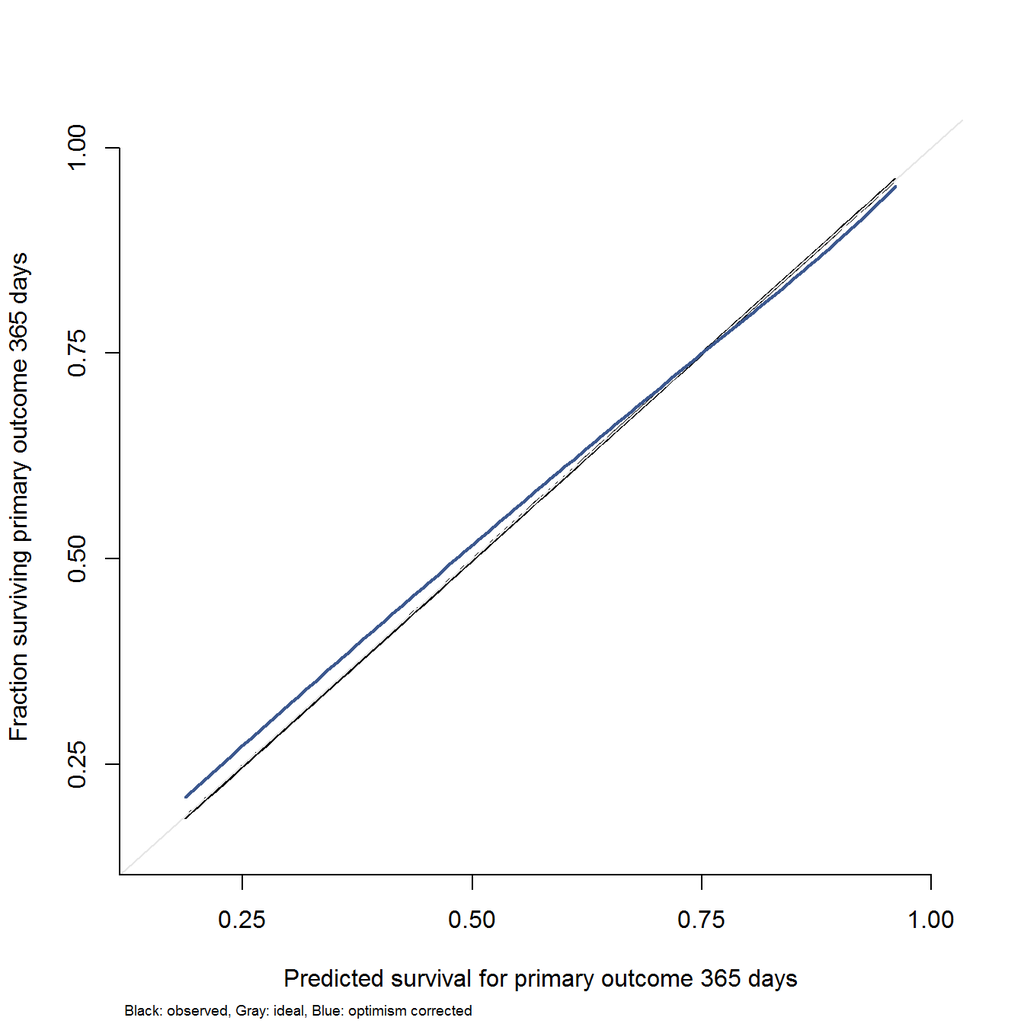

```r
ticks <- c(0,0.25,0.50,0.75,1)
plot(cal.primout,
      xlab = "Predicted survival for primary outcome 365 days",
      ylab = "Fraction surviving primary outcome 365 days",
      subtitles=FALSE,
      cex.subtitles = .5,
      riskdist=FALSE,
      par.corrected = list(col  ="#3C588f",lwd = 2,lty = 1, pch = 18),
      lwd=2,
      xlim=c(.15,1),
      ylim= c(.15,1),
     axes=FALSE)
axis(side=1, at=ticks)
axis(side=2, at=ticks)
title(main="",
      sub="Black: observed, Gray: ideal, Blue: optimism corrected",
      cex.sub=.6, col.sub="black",
      adj=.01
      )
```

Due to our governance process we are not able to extract R objects from the National Health Service Safe Haeven were these analysis were undertaken. Because the rms R package requires to pass the fitted model to evaluate external calibration, we were unable to provide a plot like the above for our validation cohorts. However, for consistency with the external model evaluation, here we also provide a calibration plot for the risk. This plot is generated using pec R package, which permits to pass only the predicted probabilities instead of the whole cph object.

The first two plot assess the model on the whole training data and the second two use bootstrap cross-validation (B=200). Note also that for the smooth curve the difference with the plot above shown is the method used for estimation. The above plot uses a flexible hazard regression model to create the calibration curve and here we have used a nearest neighborhood approach.

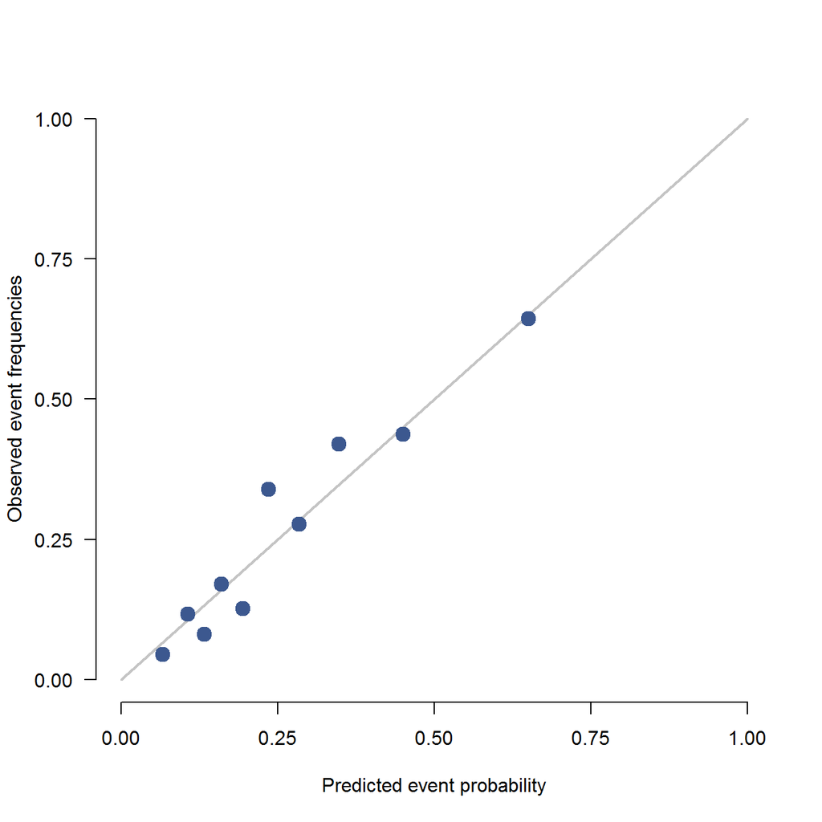

```r
calPlot(Cox_primout, type="risk", time=365,
        method="quantile",
        pch = 21  ,
        col="#3C588f",
        legend = FALSE,
        percent = FALSE,
        lty=0,
        lwd=6)
```

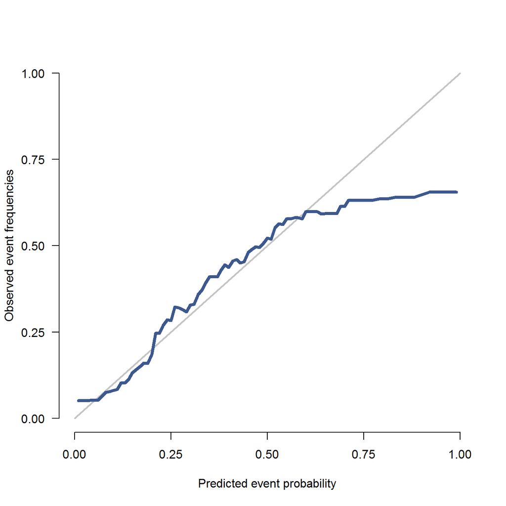

```r
calPlot(Cox_primout, type="risk", time=365,
        method="nne",
        col="#3C588f",
        legend = FALSE,
        percent = FALSE,
        lwd=4)
```

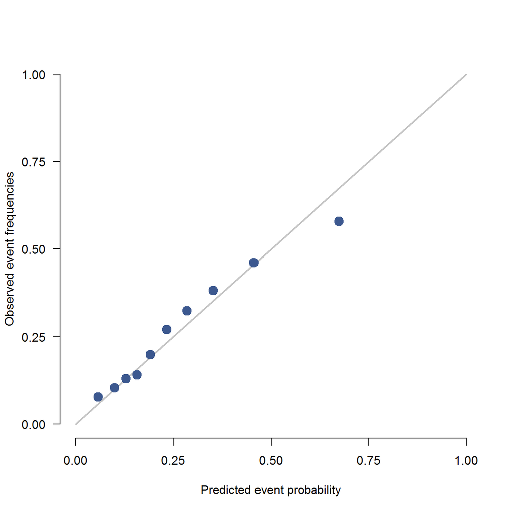

```r
set.seed(100)
calPlot(Cox_primout, type="risk", time=365,
        method="quantile",
        splitMethod="bootCv", B=200,
        col="#3C588f",
        legend = FALSE,
        percent = FALSE,
        lty=0,
        lwd=6)
```

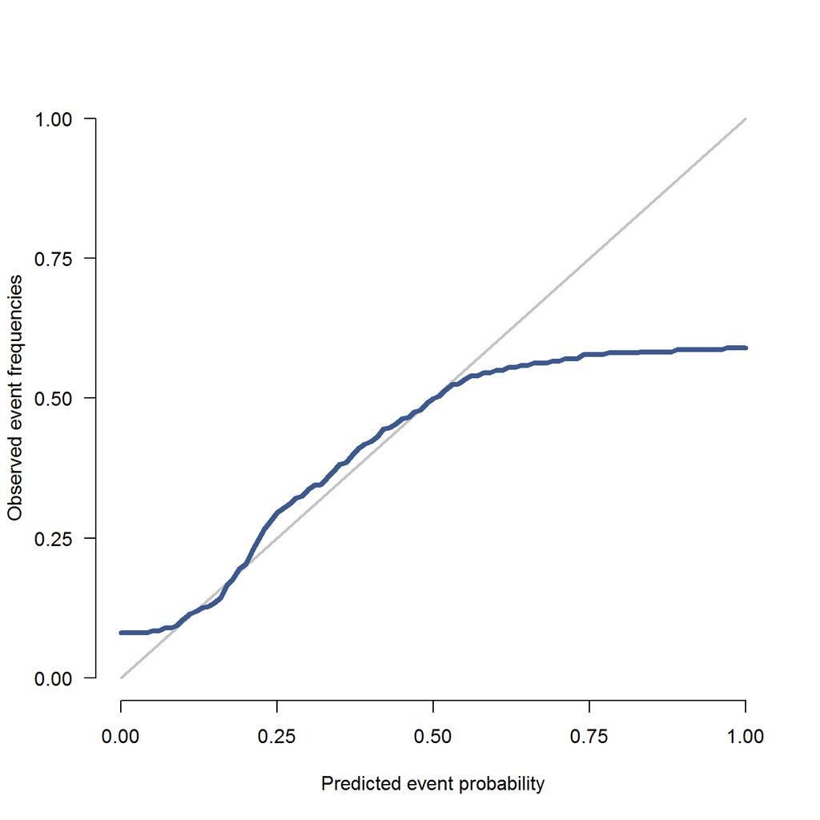

```r
calPlot(Cox_primout, type="risk", time=365,
        method="nne",
        splitMethod="bootCv", B=200,
        col="#3C588f",
        legend = FALSE,
        percent = FALSE,
        lwd=4)
```

Now that good calibration has been evaluated, we report two measures of discrimination. The first one, corresponds to the concordance or C-index:

```r
set.seed(200)
val.internal <- validate(Cox_primout, B=200)
print(("Bootstraped C-statistic:")); round((val.internal[1,5]/2 +.5),3)
```

```
## [1] "Bootstraped C-statistic:"
```

```
## [1] 0.705
```

The second, corresponds to the AUROC (area under the receiver operating characteristic):

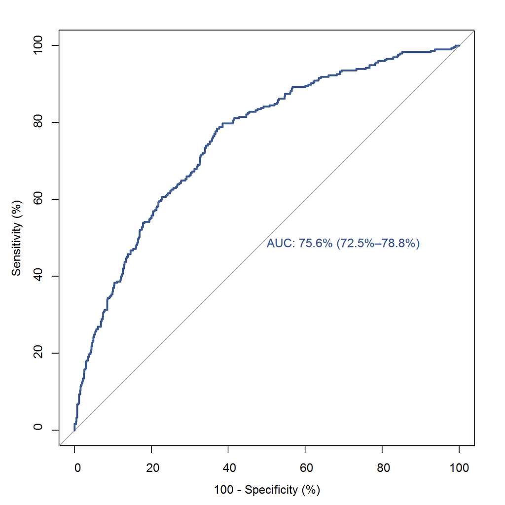

```r
data_primout <- data_TypeII_imputed_reduced
data_primout$LP <- predictrms(Cox_primout, data=data_primout)
data_primout$prob.primout = 1-S0365.primout^exp(data_primout$LP)

roc.primout <-  roc(data_primout$MIorAllcausedeath, data_primout$prob.primout,
                     auc.polygon = TRUE,
                     print.auc =TRUE,
                     ci = TRUE, percent = TRUE,
                     legacy.axis=TRUE)

plot.roc(roc.primout,
         legacy.axes = TRUE, asp=NA,
         type="l",
         lwd = 2.5,
         col="#3C588f",
         pch=21, ci=TRUE,
         print.auc=TRUE,
         xlim=c(100,0),
         ylim =c(0,100))
```

We are interested in comparing the above AUROC with that obtained from using GRACE 2.0 in the same population (after removal of two outliers).The resulting AUC is 0.71 . Below, we show results of such comparison using DeLong’s test.

```r
roc.test(roc.primout,rocgrace)
```

```
##
##  DeLong's test for two ROC curves
##
## data:  roc.primout and rocgrace
## D = 2.0893, df = 2231.2, p-value = 0.03679
## alternative hypothesis: true difference in AUC is not equal to 0
## sample estimates:
## AUC of roc1 AUC of roc2
##    75.62691    70.72301
```

Finally, we report the index of prediction accuracy (IPA) measure. This metric employs a scaled Brier score and as such encompasses discrimination and calibration.

The table below shows a Brier score of 0.11 for the proposed model and Brier score of 0.14 for the null (no covariates) resulting in IPA of 0.21.

```r
library(riskRegression)
IPA.primout <- IPA(Cox_primout, formula = Surv(days_MIorALLCAUSE, MIorAllcausedeath) ~ 1,
    times=365)
knitr::kable(IPA.primout, "simple", align="lcccc", digits = 2)
```

| Variable | times | Brier | IPA | IPA.drop |
| --- | --- | --- | --- | --- |
| Null model | 365 | 0.14 | 0.00 | 0.21 |
| Full model | 365 | 0.11 | 0.21 | 0.00 |
| rcs(Age, 4) | 365 | 0.12 | 0.16 | 0.05 |
| rcs(eGFR, 3) | 365 | 0.11 | 0.21 | 0.01 |
| logTroponin | 365 | 0.11 | 0.21 | 0.01 |
| Anaemia | 365 | 0.11 | 0.20 | 0.01 |
| MyocardialIschemia | 365 | 0.11 | 0.21 | 0.00 |
| PrevHFHospitalisation | 365 | 0.11 | 0.20 | 0.01 |
| PrevDiabetes | 365 | 0.11 | 0.21 | 0.00 |
| PrevIHD | 365 | 0.11 | 0.21 | 0.00 |
| rcs(HeartRate, 3) | 365 | 0.11 | 0.20 | 0.01 |

### 2.2.2 Covariate effects

The plots depicted below, show the covariate effects on the logarithm of the hazard for each of the predictors when holding the others fixed at their medians.

The plots for Age, eGFR and Heart Rate highlight the flexibility of introducing splines for such predictors.

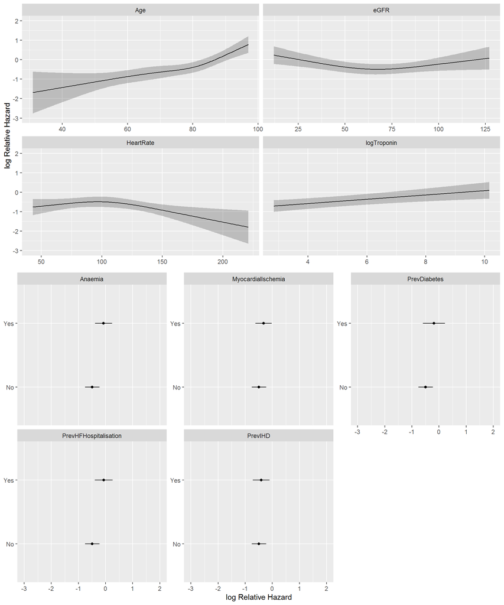

```r
ggplot(Predict(Cox_primout), sepdiscrete = "vertical", nlevels = 6, vnames = 'names')
```

### 2.2.3 Forest plot

We use a forest plot to illustrate hazard ratios with 95% confidence intervals for each of the covariates included in the model. Note that for those covariates that used restricted cubic splines the reported hazard ratios are reported with respect to the lower and upper quartiles of the data (such reference values are provided next to the covariate name).

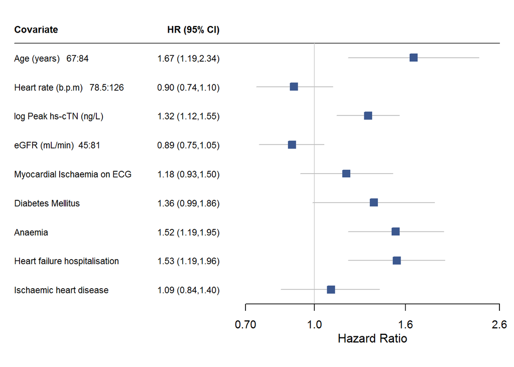

```r
tabletext_primout <- cbind( c("Covariate", "Age (years)   67:84", "Heart rate (b.p.m)   78.5:126", "log Peak hs-cTN (ng/L)",
                              "eGFR (mL/min)  45:81", "Myocardial Ischaemia on ECG", "Diabetes Mellitus",
                              "Anaemia", "Heart failure hospitalisation", "Ischaemic heart disease" ),
                               c("HR (95% CI)", "1.67 (1.19,2.34)", "0.90 (0.74,1.10)",
                                 "1.32 (1.12,1.55)", "0.89 (0.75,1.05)", "1.18 (0.93,1.50)",
                                 "1.36 (0.99,1.86)","1.52 (1.19,1.95)",
                                 "1.53 (1.19,1.96)", "1.09 (0.84,1.40)" ))

primout_HR <- structure(list( mean  = c(NA, 1.67, 0.90, 1.32, 0.89, 1.18, 1.36, 1.52, 1.53, 1.09),
                              lower = c(NA, 1.19, 0.74, 1.12, 0.75, 0.93, 0.99, 1.19, 1.19, 0.84),
                              upper = c(NA, 2.34, 1.10, 1.55, 1.05, 1.50, 1.86, 1.95, 1.96, 1.40)),
                          .Names = c("mean", "lower", "upper"),
                           row.names = c(NA, -8L),
                           class = "data.frame")


primout_HR %>%
          forestplot(labeltext = tabletext_primout,
                    is.summary = c(rep(TRUE,1), rep(FALSE, 9)),
                    boxsize = .25,
                    clip = c(.6, 2.6),
                    txt_gp = fpTxtGp(label = gpar(cex=.72), ticks = gpar(cex=.9), xlab = gpar(cex=1)),
                    xlog = TRUE,
                    col = fpColors( box="#3C588f"),
                    xticks = c(.7,1,1.6,2.6),
                    xlab ="Hazard Ratio",
                    hrzl_lines = gpar(col="#444444"))
```

```r
knitr::kable(summary(Cox_primout),digits=2, align="lccccccc","simple")
```

|  | Low | High | Diff. | Effect | S.E. | Lower 0.95 | Upper 0.95 | Type |
| --- | --- | --- | --- | --- | --- | --- | --- | --- |
| Age | 67.00 | 84.0 | 17.00 | 0.51 | 0.17 | 0.18 | 0.85 | 1 |
| Hazard Ratio | 67.00 | 84.0 | 17.00 | 1.67 | NA | 1.19 | 2.34 | 2 |
| eGFR | 45.00 | 81.0 | 36.00 | -0.12 | 0.09 | -0.29 | 0.05 | 1 |
| Hazard Ratio | 45.00 | 81.0 | 36.00 | 0.88 | NA | 0.75 | 1.05 | 2 |
| logTroponin | 3.87 | 6.4 | 2.52 | 0.28 | 0.08 | 0.12 | 0.44 | 1 |
| Hazard Ratio | 3.87 | 6.4 | 2.52 | 1.32 | NA | 1.12 | 1.55 | 2 |
| HeartRate | 78.50 | 126.0 | 47.50 | -0.10 | 0.10 | -0.30 | 0.09 | 1 |
| Hazard Ratio | 78.50 | 126.0 | 47.50 | 0.90 | NA | 0.74 | 1.10 | 2 |
| Anaemia - Yes:No | 1.00 | 2.0 | NA | 0.42 | 0.12 | 0.17 | 0.66 | 1 |
| Hazard Ratio | 1.00 | 2.0 | NA | 1.52 | NA | 1.19 | 1.94 | 2 |
| MyocardialIschemia - Yes:No | 1.00 | 2.0 | NA | 0.17 | 0.12 | -0.07 | 0.41 | 1 |
| Hazard Ratio | 1.00 | 2.0 | NA | 1.18 | NA | 0.93 | 1.50 | 2 |
| PrevHFHospitalisation - Yes:No | 1.00 | 2.0 | NA | 0.42 | 0.13 | 0.18 | 0.67 | 1 |
| Hazard Ratio | 1.00 | 2.0 | NA | 1.53 | NA | 1.19 | 1.96 | 2 |
| PrevDiabetes - Yes:No | 1.00 | 2.0 | NA | 0.31 | 0.16 | -0.01 | 0.62 | 1 |
| Hazard Ratio | 1.00 | 2.0 | NA | 1.36 | NA | 0.99 | 1.86 | 2 |
| PrevIHD - Yes:No | 1.00 | 2.0 | NA | 0.08 | 0.13 | -0.17 | 0.34 | 1 |
| Hazard Ratio | 1.00 | 2.0 | NA | 1.09 | NA | 0.84 | 1.41 | 2 |

```r
# summary(Cox_primout, Age=c(40,60))[c(1:2),]
```

### 2.2.4 CIF

We create 3 risk groups and produce a CIF plot for each of the categories. The groups were defined based on the distribution of the estimated probabilities.

```r
print("Risk category cut-off points:")
```

```
## [1] "Risk category cut-off points:"
```

```r
round(summary(data_primout$prob.primout),2) # extract quantiles to define threshold of risk categories
```

```
##    Min. 1st Qu.  Median    Mean 3rd Qu.    Max.
##    0.01    0.13    0.21    0.26    0.34    0.99
```

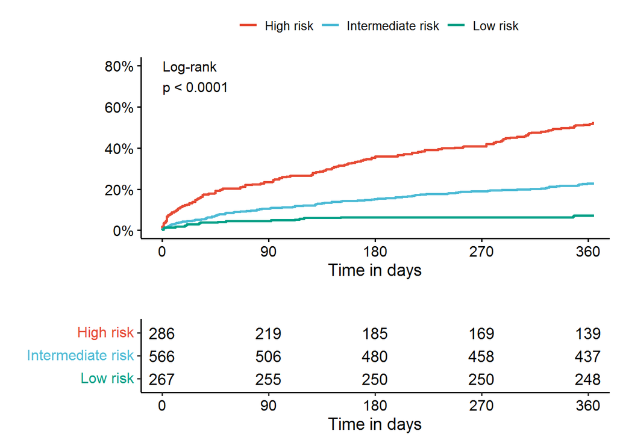

```r
data_primout$riskgroup <- ifelse(data_primout$prob.primout <= 0.13, "Low",
                                ifelse(data_primout$prob.primout > 0.13 &
                                        data_primout$prob.primout <= 0.34, "Intermediate",
                                        ifelse (data_primout$prob.primout > 0.34 , "High", "0" )))

survcurve.primout <-  survfit(Surv(days_MIorALLCAUSE, MIorAllcausedeath) ~ riskgroup, data = data_primout)

ggsurvplot(survcurve.primout, fun = "event",
           pval = TRUE, pval.method = TRUE, pval.size = 4, pval.coord = c(.2,.7),
           pval.method.size = 4, pval.method.coord = c(.2, .8),
           risk.table = TRUE, risk.table.title = "",
           xlim = c(0, 360), break.x.by = 90,
           xlab = "Time in days",
           ylab = " ",
           legend.labs = c("High risk","Intermediate risk", "Low risk"),
           palette = "npg",
           legend.title = "",
           surv.scale = "percent",
           surv.plot.height = .95,
           risk.table.height = .35,
           censor=FALSE
           )
```

### 2.2.5 Nomogram

A nomogram can be employed to manually obtain the predicted probabilty of the primary outcome at 365 days.

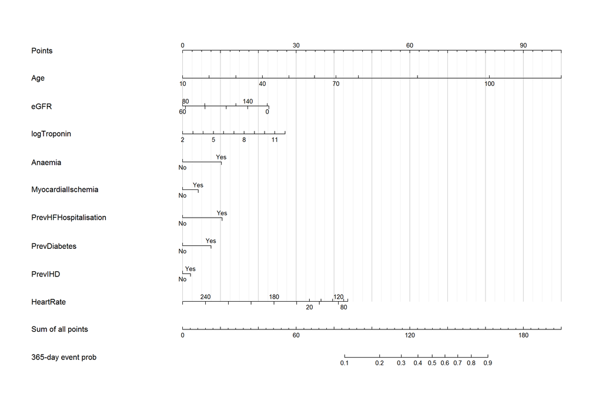

```r
surv.primout <- Survival(Cox_primout)

nom <- nomogram(Cox_primout, fun = function(x) 1-surv.primout(365,x),
                funlabel = c("365-day event prob"), lp = F)

plot(nom, xfra = .4, total.points.label = "Sum of all points",
     cex.axis = .8, tcl = .3, lmgp = 0.1, col.grid = gray(c(.8,.95)),
     cex.var = 1, label.every = 3, ia.space = 2.7)
```

# 3 Secondary outcome CPH model

We employ the same covariates studied above to fit a Cox PH model for the secondary outcome. Note that in this setting competing events are treated as censored.

```r
Cox_secout <- cph(Surv(timetoevent_cr, status==1)~ rcs(Age,4) + rcs(eGFR,3) + logTroponin + Anaemia +
                                                    MyocardialIschemia + PrevHFHospitalisation +
                                                    PrevDiabetes + PrevIHD + rcs(HeartRate, 3),
                  data = data_TypeII_imputed_reduced,
                  x = TRUE, y = TRUE, surv = TRUE, model = TRUE, time.inc = 365)

print(Cox_secout)
```

```
## Cox Proportional Hazards Model
##
##  cph(formula = Surv(timetoevent_cr, status == 1) ~ rcs(Age, 4) +
##      rcs(eGFR, 3) + logTroponin + Anaemia + MyocardialIschemia +
##      PrevHFHospitalisation + PrevDiabetes + PrevIHD + rcs(HeartRate,
##      3), data = data_TypeII_imputed_reduced, model = TRUE, x = TRUE,
##      y = TRUE, surv = TRUE, time.inc = 365)
##
##                      Model Tests       Discrimination
##                                           Indexes
##  Obs      1119    LR chi2    128.99    R2       0.126
##  Events    162    d.f.           13    Dxy      0.475
##  Center 0.5294    Pr(> chi2) 0.0000    g        0.978
##                   Score chi2 150.17    gr       2.658
##                   Pr(> chi2) 0.0000
##
##                            Coef    S.E.   Wald Z Pr(>|Z|)
##  Age                       -0.0048 0.0214 -0.22  0.8234
##  Age'                       0.0174 0.0364  0.48  0.6324
##  Age''                      0.1561 0.2487  0.63  0.5303
##  eGFR                      -0.0109 0.0069 -1.60  0.1104
##  eGFR'                      0.0080 0.0088  0.90  0.3663
##  logTroponin                0.1535 0.0436  3.52  0.0004
##  Anaemia=Yes                0.4571 0.1680  2.72  0.0065
##  MyocardialIschemia=Yes     0.0677 0.1661  0.41  0.6835
##  PrevHFHospitalisation=Yes  0.7901 0.1698  4.65  <0.0001
##  PrevDiabetes=Yes           0.3546 0.2093  1.69  0.0902
##  PrevIHD=Yes                0.1745 0.1800  0.97  0.3325
##  HeartRate                 -0.0015 0.0059 -0.25  0.8049
##  HeartRate'                -0.0065 0.0088 -0.74  0.4570
##
```

```r
anova(Cox_secout)
```

```
##                 Wald Statistics          Response: Surv(timetoevent_cr, status == 1)
##
##  Factor                Chi-Square d.f. P
##  Age                    29.25      3   <.0001
##   Nonlinear             11.67      2   0.0029
##  eGFR                    3.44      2   0.1791
##   Nonlinear              0.82      1   0.3663
##  logTroponin            12.40      1   0.0004
##  Anaemia                 7.41      1   0.0065
##  MyocardialIschemia      0.17      1   0.6835
##  PrevHFHospitalisation  21.64      1   <.0001
##  PrevDiabetes            2.87      1   0.0902
##  PrevIHD                 0.94      1   0.3325
##  HeartRate               4.44      2   0.1087
##   Nonlinear              0.55      1   0.4570
##  TOTAL NONLINEAR        13.75      4   0.0082
##  TOTAL                 131.66     13   <.0001
```

```r
Cox_secout %>% tbl_regression(exponentiate=TRUE)
```

| **Characteristic** | **HR**<sup>1</sup> | **95% CI**<sup>1</sup> | **p-value** |
| --- | --- | --- | --- |
| Age | 1.00 | 0.95, 1.04 | 0.8 |
| Age' | 1.02 | 0.95, 1.09 | 0.6 |
| Age'' | 1.17 | 0.72, 1.90 | 0.5 |
| eGFR | 0.99 | 0.98, 1.00 | 0.11 |
| eGFR' | 1.01 | 0.99, 1.03 | 0.4 |
| logTroponin | 1.17 | 1.07, 1.27 | <0.001 |
| Anaemia=Yes | 1.58 | 1.14, 2.20 | 0.006 |
| MyocardialIschemia=Yes | 1.07 | 0.77, 1.48 | 0.7 |
| PrevHFHospitalisation=Yes | 2.20 | 1.58, 3.07 | <0.001 |
| PrevDiabetes=Yes | 1.43 | 0.95, 2.15 | 0.090 |
| PrevIHD=Yes | 1.19 | 0.84, 1.69 | 0.3 |
| HeartRate | 1.00 | 0.99, 1.01 | 0.8 |
| HeartRate' | 0.99 | 0.98, 1.01 | 0.5 |

<sup>*1*</sup> HR = Hazard Ratio, CI = Confidence Interval

The linear predictor is shown below:

```r
Function(Cox_secout)
```

function (Age = 77, eGFR = 65, logTroponin = 4.8202816, Anaemia = “No”, MyocardialIschemia = “No”, PrevHFHospitalisation = “No”, PrevDiabetes = “No”, PrevIHD = “No”, HeartRate = 100) { -0.52936936 - 0.0047846242 * Age + 9.4179917e-06 * pmax(Age - 48, 0)^3 + 8.4420509e-05 * pmax(Age - 71, 0)^3 - 0.00020933838 * pmax(Age - 81, 0)^3 + 0.00011549988 * pmax(Age - 91, 0)^3 - 0.010949948 * eGFR + 1.8856582e-06 * pmax(eGFR - 31, 0)^3 - 3.9537994e-06 * pmax(eGFR - 65, 0)^3 + 2.0681412e-06 * pmax(eGFR - 96, 0)^3 + 0.15347577 * logTroponin + 0.45709098 * (Anaemia == “Yes”) + 0.067704053 * (MyocardialIschemia == “Yes”) + 0.79012042 * (PrevHFHospitalisation == “Yes”) + 0.35455466 * (PrevDiabetes == “Yes”) + 0.17447512 * (PrevIHD == “Yes”) - 0.0014624885 * HeartRate - 8.8541454e-07 * pmax(HeartRate - 65, 0)^3 + 1.493052e-06 * pmax(HeartRate - 100, 0)^3 - 6.0763743e-07 * pmax(HeartRate - 151, 0)^3 } <environment: 0x00000000399d9268>

In addition, the baseline survival function at 365 days is reported.

```r
S0 <- exp(-basehaz(Cox_secout)$hazard)
S0365.secout <- S0[length(S0)]
S0365.secout
```

```
## [1] 0.8795273
```

## 3.1 Validation

As with the model for the primary outcome, we report internal calibration and discrimination.

The resulting calibration plot with bias corrected estimates obtained with rms R package is shown below:

```r
cal.secout <- calibrate(Cox_secout, u=365, cmethod = "hare", B=200, subtitles = FALSE, legend = FALSE, riskdist = FALSE )
```

```
## Using Cox survival estimates at 365 Days
```

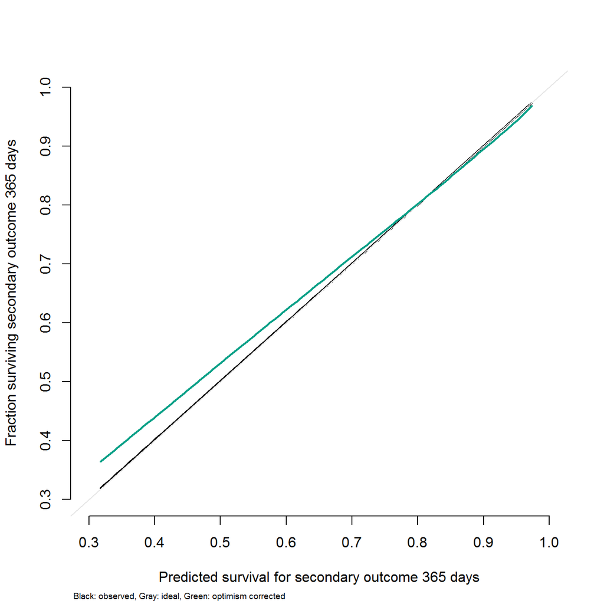

```r
xticks =seq(.3,1, by=.1)

plot(cal.secout,
     xlab = "Predicted survival for secondary outcome 365 days" ,
     ylab = "Fraction surviving secondary outcome 365 days" ,
     subtitles = FALSE,
     cex.subtitles = .5,
     riskdist=FALSE,
     par.corrected=list(col= "#00a087ff",lwd=2,lty=1, pch=18),
     lwd=2,
     xlim=c(.3,1),
     ylim=c(.3,1),
     axes=FALSE)
axis(side=1, at=xticks)
axis(side=2, at= xticks)
title(main="",
      sub="Black: observed, Gray: ideal, Green: optimism corrected",
      cex.sub=.6, col.sub="black",
      adj=.01
      )
```

We also report calibration plots from pec R package. First two plots corresponds to risk calibration in the whole training data, one using binning and the other using a smoothing method. The second two plots show calibration using bootstrap cross-validation (B=200), the first with binning of predicted probabilities and the second using a smoothing approach.

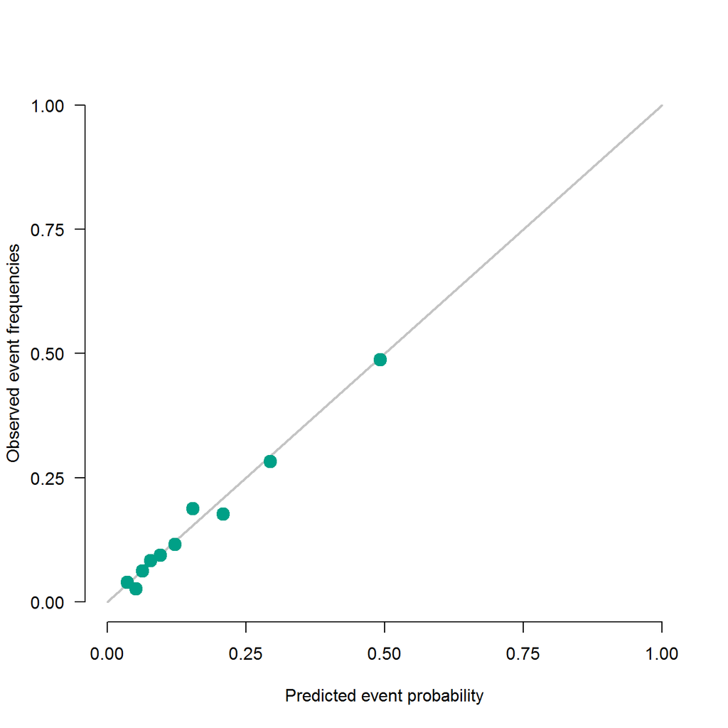

```r
calPlot(Cox_secout,
        type="risk",
        time=365,
        method="quantile",
        col="#00a087ff",
        legend = FALSE,
        percent = FALSE,
        lty=0,
        lwd=6)
```

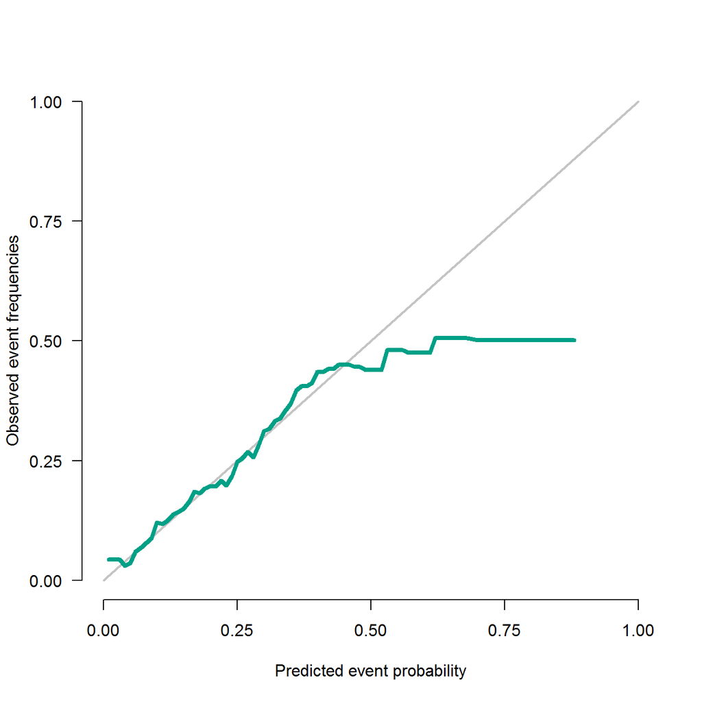

```r
calPlot(Cox_secout,
        type="risk", time=365,
        method="nne",
        col="#00a087ff",
       legend = FALSE,
       percent = FALSE,
       lwd=4)
```

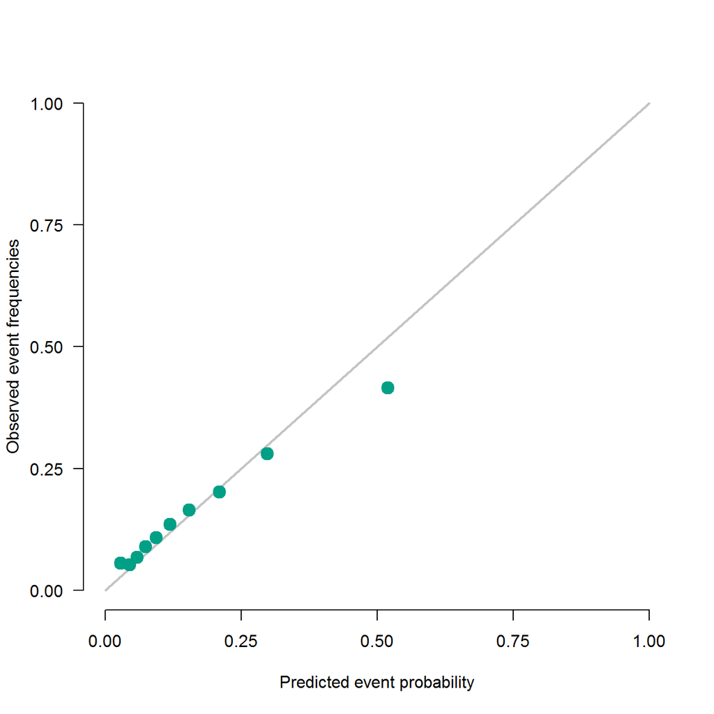

```r
set.seed(100)
calPlot(Cox_secout,
        type="risk", time=365,
        method="quantile",
        splitMethod="bootCv", B=200,
        col="#00a087ff",
        legend = FALSE,
        percent = FALSE,
        lty=0,
        lwd=6)
```

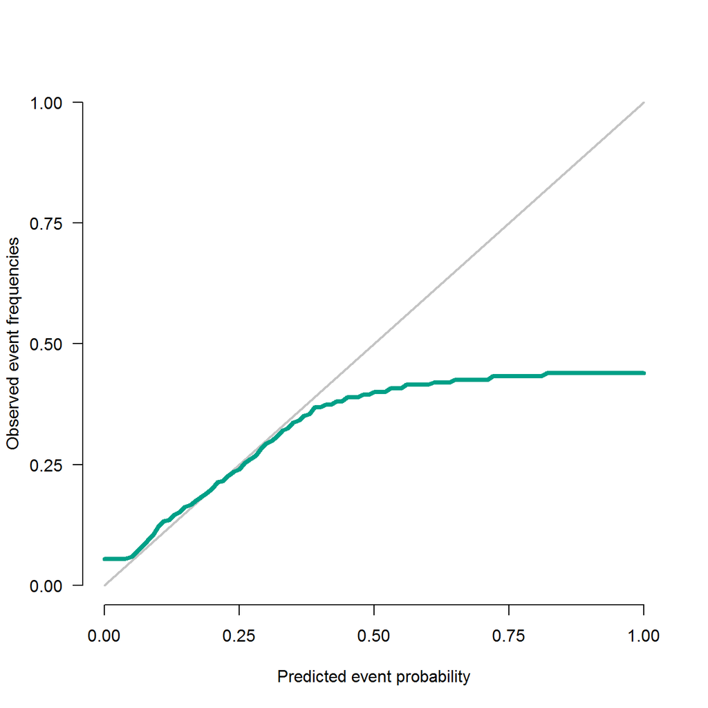

```r
calPlot(Cox_secout,
        type="risk", time=365,
        method="nn",
        splitMethod="bootCv", B=200,
        col="#00a087ff",
        legend = FALSE,
        percent = FALSE,
        lwd=4)
```

As measures of discrimination performance we show concordance index and AUROC

```r
set.seed(200)
val.internal <- validate(Cox_secout, B=200)
print(("Bootstraped C-statistic:")); round((val.internal[1,5]/2 +.5),3)
```

```
## [1] "Bootstraped C-statistic:"
```

```
## [1] 0.717
```

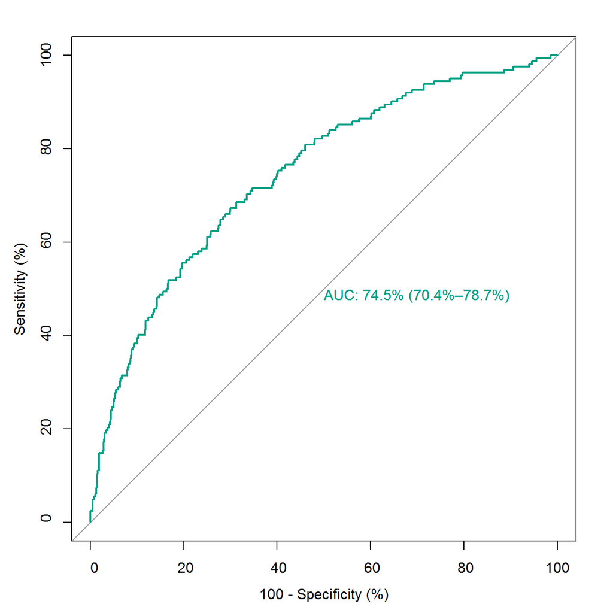

```r
data_secout <- data_TypeII_imputed_reduced
data_secout$LP <- predictrms(Cox_secout, data = data_secout)
data_secout$prob.secout = 1-S0365.secout^exp(data_secout$LP)

roc.secout <-  roc(data_secout$secondary_outcome, data_secout$prob.secout,
                    auc.polygon = TRUE,
                    print.auc =TRUE,
                    ci = TRUE,
                    percent = TRUE,
                    legacy.axis=TRUE)
plot.roc(roc.secout,
         asp=NA,
         legacy.axes = TRUE,
         type="l",
         col="#00a087ff",
         pch=21,
         ci=TRUE,
         print.auc=TRUE,
         ylim=c(0,100))
```

Finally, we report the index of prediction accuracy (IPA) measure. This metric employs a scaled Brier score and as such encompasses discrimination and calibration. Similar to the results for the primary outcome we obtained an IPA of 0.21.

```r
IPA.secout <- IPA(Cox_secout, formula = Surv(timetoevent_cr, status == 1)~ 1,
    times=365)
knitr::kable(IPA.secout, "simple", align="lcccc", digits = 2)
```

| Variable | times | Brier | IPA | IPA.drop |
| --- | --- | --- | --- | --- |
| Null model | 365 | 0.11 | 0.00 | 0.21 |
| Full model | 365 | 0.09 | 0.21 | 0.00 |
| rcs(Age, 4) | 365 | 0.09 | 0.18 | 0.03 |
| rcs(eGFR, 3) | 365 | 0.09 | 0.21 | 0.01 |
| logTroponin | 365 | 0.09 | 0.19 | 0.02 |
| Anaemia | 365 | 0.09 | 0.20 | 0.01 |
| MyocardialIschemia | 365 | 0.09 | 0.21 | 0.00 |
| PrevHFHospitalisation | 365 | 0.09 | 0.18 | 0.04 |
| PrevDiabetes | 365 | 0.09 | 0.21 | 0.00 |
| PrevIHD | 365 | 0.09 | 0.21 | 0.00 |
| rcs(HeartRate, 3) | 365 | 0.09 | 0.21 | 0.01 |

Below, we show code to obtain a combined ROC curve with the results of the primary and secondary outcome models.

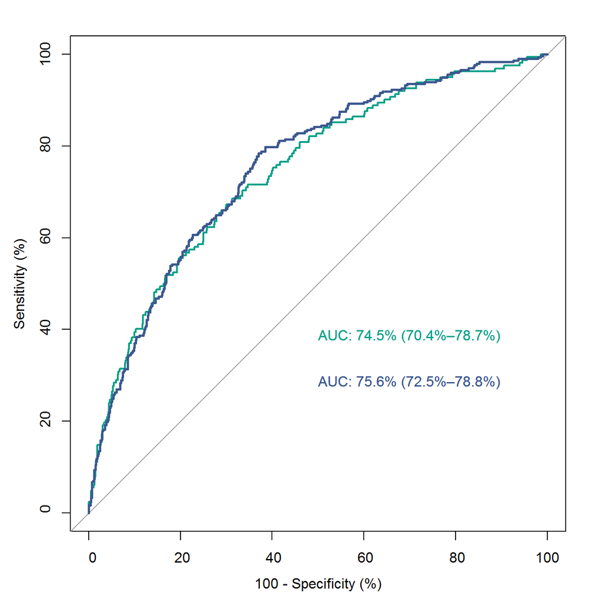

Similarly, we now combine internal calibration plots for the primary and secondary outcome models.

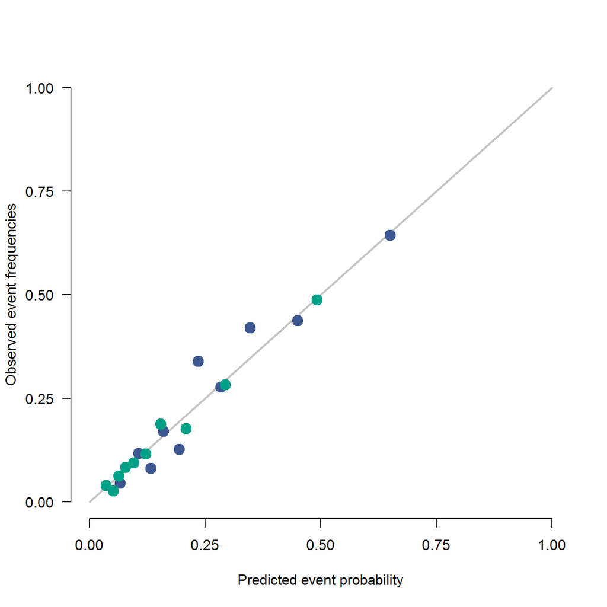

```r
calPlot(Cox_primout,
        type="risk", time=365,
        method="quantile",
        col="#3C588f",
        legend = FALSE,
        percent = FALSE,
        lty=0,
        lwd=6)
calPlot(Cox_secout,
        type="risk", time=365,
        method="quantile",
        col="#00a087ff",
        legend = FALSE,
        percent = FALSE,
        lty=0,
        add=TRUE,
        lwd=6)
```

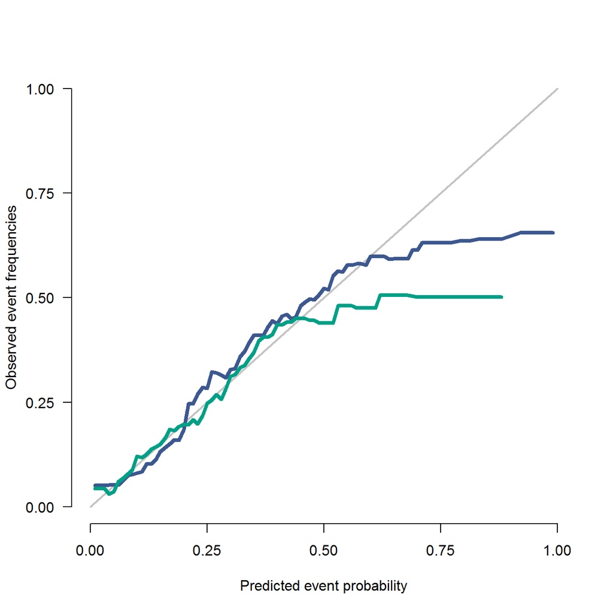

```r
calPlot(Cox_primout,
        type="risk", time=365,
        method="nne",
        col="#3C588f",
       legend = FALSE,
       percent = FALSE,
       lwd=4)
calPlot(Cox_secout,
        type="risk", time=365,
        method="nne",
        col="#00a087ff",
        legend = FALSE,
        percent = FALSE,
        add=TRUE,
        lwd=4)
```

## 3.2 Covariate effects

We show predictor effects on the log hazard. Note the non-linear relationship for Age, eGFR, and Heart rate.

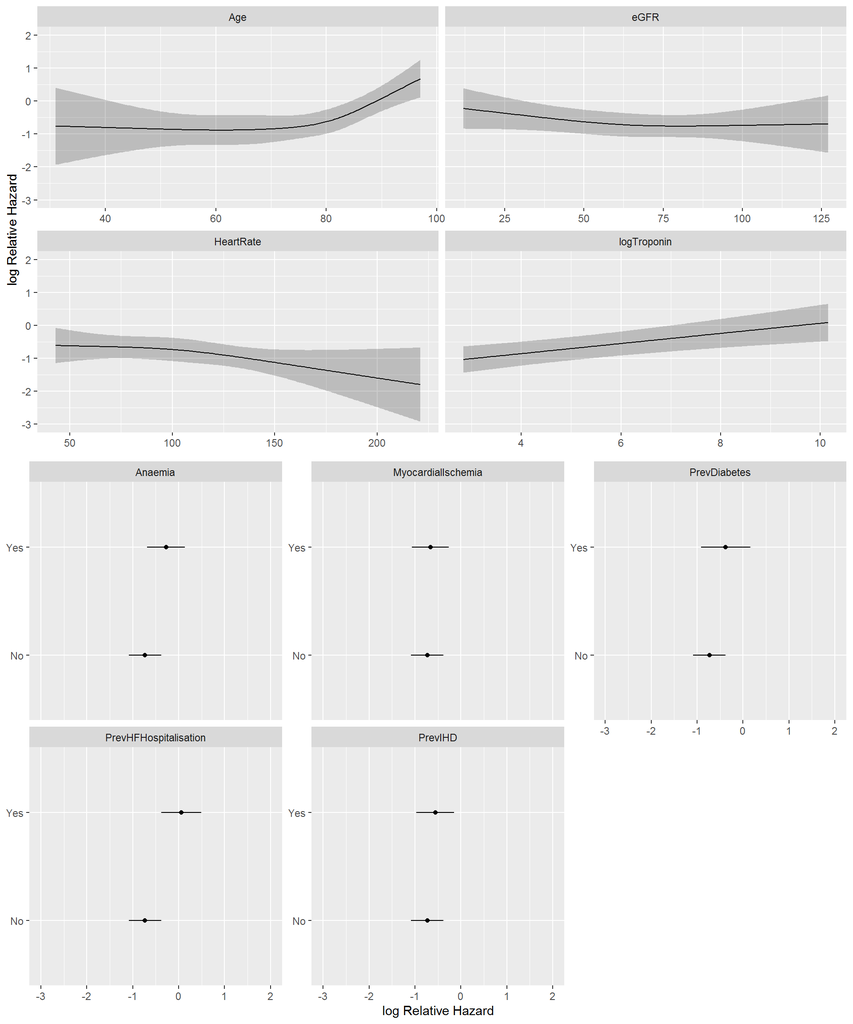

```r
ggplot(Predict(Cox_secout), sepdiscrete = "vertical", nlevels = 6,vnames ='names')
```

## 3.3 Forest plot

We use a forest plot to illustrate hazard ratios with 95% confidence intervals for each of the covariates included in the model. Note that for those covariates that used restricted cubic splines the reported hazard ratios are reported with respect to the lower and upper quartiles of the data (such reference values are provided next to the covariate name).

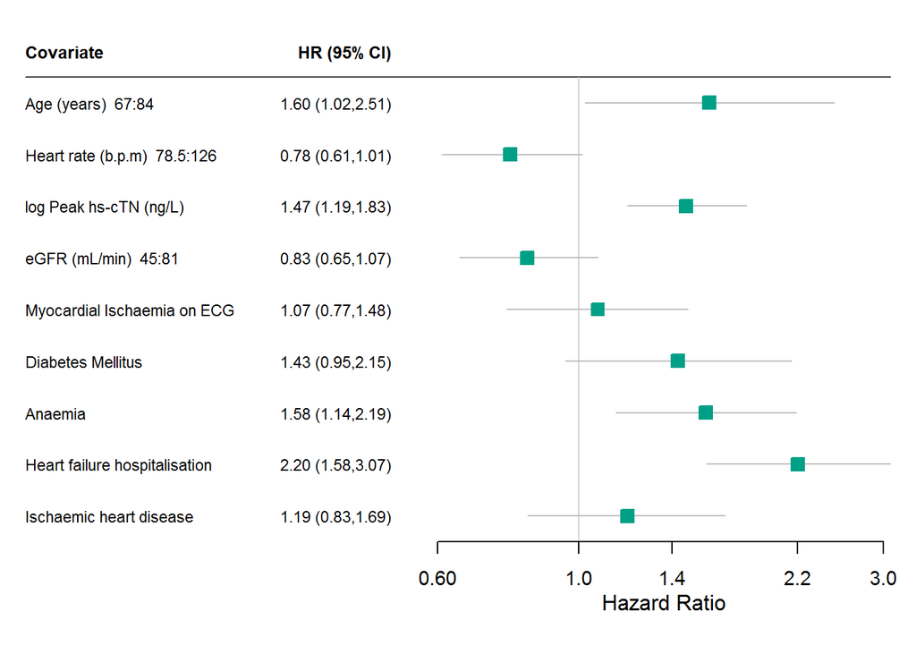

```r
tabletext_secout<- cbind(c("Covariate", "Age (years)  67:84", "Heart rate (b.p.m)  78.5:126",
                           "log Peak hs-cTN (ng/L)",
                           "eGFR (mL/min)  45:81", "Myocardial Ischaemia on ECG", "Diabetes Mellitus",
                           "Anaemia", "Heart failure hospitalisation", "Ischaemic heart disease"),
                         c("HR (95% CI)", "1.60 (1.02,2.51)", "0.78 (0.61,1.01)", "1.47 (1.19,1.83)",
                           "0.83 (0.65,1.07)", "1.07 (0.77,1.48)", "1.43 (0.95,2.15)","1.58 (1.14,2.19)",
                           "2.20 (1.58,3.07)", "1.19 (0.83,1.69)" ))

secout_HR <- structure(list( mean  = c( NA, 1.60, 0.78, 1.47, 0.83, 1.07, 1.43, 1.58, 2.20, 1.19),
                             lower = c( NA, 1.02, 0.61, 1.19, 0.65, 0.77, 0.95, 1.14, 1.58, 0.83),
                             upper = c( NA, 2.51, 1.01, 1.83, 1.07, 1.48, 2.15, 2.19, 3.07, 1.69)),
                         .Names = c("mean", "lower", "upper"),
                         row.names = c(NA, -8L),
                         class = "data.frame")


secout_HR %>%
         forestplot(labeltext = tabletext_secout,
                    is.summary = c(rep(TRUE,1), rep(FALSE, 9)),
                    boxsize = .25,
                    clip = c(.6, 3.4),
                    txt_gp = fpTxtGp( label=gpar(cex=.72), ticks = gpar(cex=.9), xlab = gpar(cex=1)),
                    xlog = TRUE,
                    col = fpColors( box="#00a087ff"),
                    xticks = c(.6,1, 1.4,2.2,3),
                    xlab = "Hazard Ratio",
                    hrzl_lines = gpar(col="#444444"))
```

```r
knitr::kable(summary(Cox_secout), digits=2, "simple", align="lccccccc")
```

|  | Low | High | Diff. | Effect | S.E. | Lower 0.95 | Upper 0.95 | Type |
| --- | --- | --- | --- | --- | --- | --- | --- | --- |
| Age | 67.00 | 84.0 | 17.00 | 0.47 | 0.23 | 0.02 | 0.92 | 1 |
| Hazard Ratio | 67.00 | 84.0 | 17.00 | 1.61 | NA | 1.02 | 2.52 | 2 |
| eGFR | 45.00 | 81.0 | 36.00 | -0.18 | 0.13 | -0.43 | 0.07 | 1 |
| Hazard Ratio | 45.00 | 81.0 | 36.00 | 0.84 | NA | 0.65 | 1.07 | 2 |
| logTroponin | 3.87 | 6.4 | 2.52 | 0.39 | 0.11 | 0.17 | 0.60 | 1 |
| Hazard Ratio | 3.87 | 6.4 | 2.52 | 1.47 | NA | 1.19 | 1.83 | 2 |
| HeartRate | 78.50 | 126.0 | 47.50 | -0.24 | 0.13 | -0.50 | 0.01 | 1 |
| Hazard Ratio | 78.50 | 126.0 | 47.50 | 0.79 | NA | 0.61 | 1.01 | 2 |
| Anaemia - Yes:No | 1.00 | 2.0 | NA | 0.46 | 0.17 | 0.13 | 0.79 | 1 |
| Hazard Ratio | 1.00 | 2.0 | NA | 1.58 | NA | 1.14 | 2.20 | 2 |
| MyocardialIschemia - Yes:No | 1.00 | 2.0 | NA | 0.07 | 0.17 | -0.26 | 0.39 | 1 |
| Hazard Ratio | 1.00 | 2.0 | NA | 1.07 | NA | 0.77 | 1.48 | 2 |
| PrevHFHospitalisation - Yes:No | 1.00 | 2.0 | NA | 0.79 | 0.17 | 0.46 | 1.12 | 1 |
| Hazard Ratio | 1.00 | 2.0 | NA | 2.20 | NA | 1.58 | 3.07 | 2 |
| PrevDiabetes - Yes:No | 1.00 | 2.0 | NA | 0.35 | 0.21 | -0.06 | 0.76 | 1 |
| Hazard Ratio | 1.00 | 2.0 | NA | 1.43 | NA | 0.95 | 2.15 | 2 |
| PrevIHD - Yes:No | 1.00 | 2.0 | NA | 0.17 | 0.18 | -0.18 | 0.53 | 1 |
| Hazard Ratio | 1.00 | 2.0 | NA | 1.19 | NA | 0.84 | 1.69 | 2 |

## 3.4 CIF

We create 3 risk groups and produce a CIF plot for each of the categories. The groups were defined based on the distribution of the estimated probabilities.

```r
print("Risk category cut-off points:")
```

```
## [1] "Risk category cut-off points:"
```

```r
round(summary(data_secout$prob.secout),2) # quantiles to define threshold of risk categories
```

```
##    Min. 1st Qu.  Median    Mean 3rd Qu.    Max.
##    0.01    0.06    0.11    0.16    0.21    0.88
```

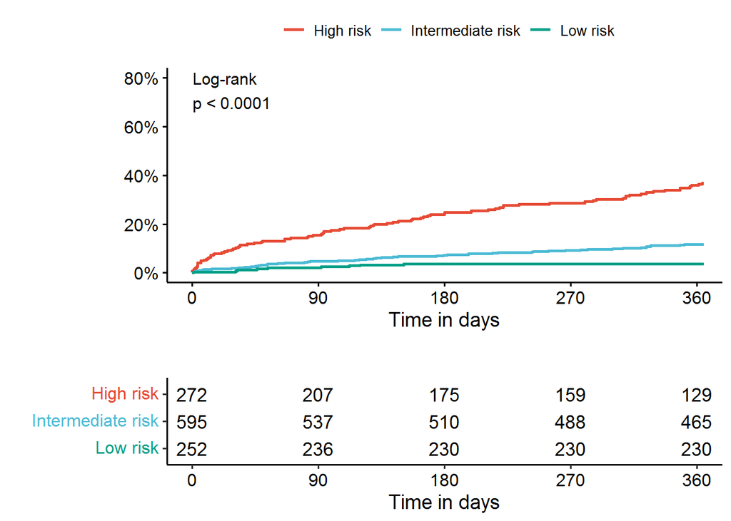

```r
data_secout$riskgroup <- ifelse(data_secout$prob.secout <= 0.06, "Low",
                                ifelse(data_secout$prob.secout > 0.06 & data_secout$prob.secout<= 0.21,
                                       "Intermediate",
                                       ifelse (data_secout$prob.secout > 0.21 , "High", "0" )))

survcurve.secout <-  survfit(Surv(timetoevent_cr, status == 1) ~ riskgroup, data = data_secout)

ggsurvplot(survcurve.secout, fun = "event",
           pval = TRUE, pval.method = TRUE,
           pval.size = 4, pval.coord = c(.2,.7), pval.method.size = 4,
           pval.method.coord = c(.2, .8),
           risk.table = TRUE,
           risk.table.title = "", xlim = c(0, 360), break.x.by = 90,
           xlab = "Time in days",
           ylab = "",
           legend.labs = c("High risk","Intermediate risk", "Low risk"),
           palette = "npg",
           surv.plot.height =.95,
           legend.title="", surv.scale="percent",
           risk.table.height=.35,
           censor = FALSE)
```

## 3.5 Nomogram

A nomogram can be employed to manually obtain the predicted probabilty of the secondary outcome at 365 days.

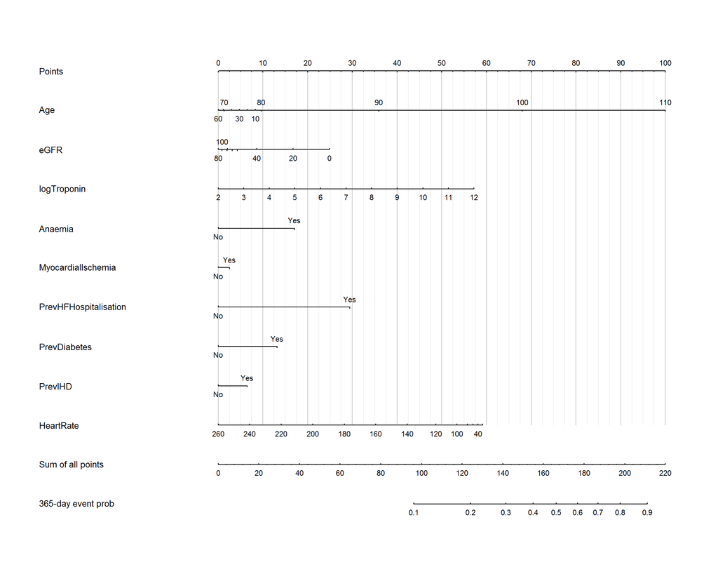

```r
surv.secout <- Survival(Cox_secout)
nom <- nomogram(Cox_secout, fun=function(x) 1-surv.secout(365,x),
                funlabel = c("365-day event prob"), lp=F)
plot(nom, xfra=.4, total.points.label = "Sum of all points", cex.axis = .7, tcl = .1, lmgp = 0.2, col.grid =
       gray(c(.8,.95)), cex.var = .8, label.every = 1, ia.space = 3.0)
```

# 4 Sensitivity analysis

## 4.1 Sensitivity analysis of missing values

In the following, we will re-fit both models after removing rows that contained missing values to check how sensitive to the imputed rows our models are:

```r
cov_remove <- c("Age", "Sex","PeakTroponin", "PrevHFHospitalisation", "Haemoglobin",
                "PrevDiabetes",  "PrevIHD","PrevCD", "MyocardialIschemia","eGFR", "HeartRate",
                 "Secout_days", "secondary_outcome","status","timetoevent_cr","days_MIorALLCAUSE",
                  "MIorAllcausedeath")

complete_data_unimputed <- na.omit(data_TypeII_reduced[, cov_remove])

complete_data_unimputed$Anaemia <- NA
complete_data_unimputed$Anaemia <- ifelse(complete_data_unimputed$Sex=="F",
                                   ifelse(complete_data_unimputed$Haemoglobin<120, "Yes", "No"),
                                  ifelse(complete_data_unimputed$Haemoglobin<130, "Yes", "No"))

complete_data_unimputed$Anaemia <- as.factor(complete_data_unimputed$Anaemia)
complete_data_unimputed$logTroponin <- log(complete_data_unimputed$PeakTroponin)
complete_data_unimputed <- as.data.frame(complete_data_unimputed)
```

### 4.1.1 Primary outcome

```r
d = datadist(complete_data_unimputed)
options(datadist = "d")

complete_Cox_primout <- cph(Surv(days_MIorALLCAUSE, MIorAllcausedeath)~ rcs(Age, c(48,71,81,91)) +
                                                                        rcs(eGFR,c(31,65,96)) +
                                                                         logTroponin +  Anaemia +
                                                                          MyocardialIschemia +
                                                                          PrevHFHospitalisation +
                                                                          PrevDiabetes +
                                                                          PrevIHD +
                                                                          rcs(HeartRate,c(65,100,151)),
                               data = complete_data_unimputed,
                               x = TRUE, y = TRUE, surv = TRUE, model = TRUE, time.inc = 365)

print(complete_Cox_primout)
```

```
## Cox Proportional Hazards Model
##
##  cph(formula = Surv(days_MIorALLCAUSE, MIorAllcausedeath) ~ rcs(Age,
##      c(48, 71, 81, 91)) + rcs(eGFR, c(31, 65, 96)) + logTroponin +
##      Anaemia + MyocardialIschemia + PrevHFHospitalisation + PrevDiabetes +
##      PrevIHD + rcs(HeartRate, c(65, 100, 151)), data = complete_data_unimputed,
##      model = TRUE, x = TRUE, y = TRUE, surv = TRUE, time.inc = 365)
##
##                      Model Tests       Discrimination
##                                           Indexes
##  Obs       817    LR chi2    152.27    R2       0.176
##  Events    210    d.f.           13    Dxy      0.466
##  Center 2.0325    Pr(> chi2) 0.0000    g        0.959
##                   Score chi2 176.33    gr       2.610
##                   Pr(> chi2) 0.0000
##
##                            Coef    S.E.   Wald Z Pr(>|Z|)
##  Age                        0.0152 0.0223  0.68  0.4955
##  Age'                      -0.0011 0.0356 -0.03  0.9764
##  Age''                      0.2760 0.2374  1.16  0.2449
##  eGFR                      -0.0169 0.0060 -2.83  0.0046
##  eGFR'                      0.0136 0.0077  1.76  0.0780
##  logTroponin                0.1185 0.0382  3.10  0.0019
##  Anaemia=Yes                0.4820 0.1482  3.25  0.0011
##  MyocardialIschemia=Yes     0.0663 0.1475  0.45  0.6528
##  PrevHFHospitalisation=Yes  0.5607 0.1493  3.76  0.0002
##  PrevDiabetes=Yes           0.3315 0.1884  1.76  0.0785
##  PrevIHD=Yes               -0.0470 0.1556 -0.30  0.7627
##  HeartRate                  0.0087 0.0055  1.58  0.1145
##  HeartRate'                -0.0179 0.0082 -2.20  0.0279
##
```

Let us compare the tables of the estimated coefficients:

```r
unimputed_prim <- complete_Cox_primout %>% tbl_regression(exponentiate=TRUE)
imputed_prim  <- Cox_primout %>% tbl_regression(exponentiate=TRUE)

tbl_merge(tbls=list(imputed_prim, unimputed_prim),
          tab_spanner = c("**Imputed**", "**Unimputed**"))
```

| **Characteristic** | **Imputed** **HR**<sup>1</sup> | **Imputed** **95% CI**<sup>1</sup> | **Imputed** **p-value** | **Unimputed** **HR**<sup>1</sup> | **Unimputed** **95% CI**<sup>1</sup> | **Unimputed** **p-value** |
| --- | --- | --- | --- | --- | --- | --- |
| Age | 1.03 | 0.99, 1.07 | 0.14 | 1.02 | 0.97, 1.06 | 0.5 |
| Age' | 0.99 | 0.93, 1.05 | 0.7 | 1.00 | 0.93, 1.07 | >0.9 |
| Age'' | 1.26 | 0.86, 1.85 | 0.2 | 1.32 | 0.83, 2.10 | 0.2 |
| eGFR | 0.98 | 0.97, 0.99 | <0.001 | 0.98 | 0.97, 0.99 | 0.005 |
| eGFR' | 1.02 | 1.01, 1.03 | 0.003 | 1.01 | 1.00, 1.03 | 0.078 |
| logTroponin | 1.12 | 1.05, 1.19 | <0.001 | 1.13 | 1.04, 1.21 | 0.002 |
| Anaemia=Yes | 1.52 | 1.19, 1.94 | <0.001 | 1.62 | 1.21, 2.17 | 0.001 |
| MyocardialIschemia=Yes | 1.18 | 0.93, 1.50 | 0.2 | 1.07 | 0.80, 1.43 | 0.7 |
| PrevHFHospitalisation=Yes | 1.53 | 1.19, 1.96 | <0.001 | 1.75 | 1.31, 2.35 | <0.001 |
| PrevDiabetes=Yes | 1.36 | 0.99, 1.86 | 0.057 | 1.39 | 0.96, 2.02 | 0.079 |
| PrevIHD=Yes | 1.09 | 0.84, 1.41 | 0.5 | 0.95 | 0.70, 1.29 | 0.8 |
| HeartRate | 1.01 | 1.00, 1.02 | 0.2 | 1.01 | 1.00, 1.02 | 0.11 |
| HeartRate' | 0.98 | 0.97, 1.00 | 0.027 | 0.98 | 0.97, 1.00 | 0.028 |

<sup>*1*</sup> HR = Hazard Ratio, CI = Confidence Interval

Baseline survival function for non-imputed dataset.

```r
# New s0365 for unimputed data for primary outcome
S0unimputed = exp(-basehaz(complete_Cox_primout)$hazard)
s0365.primout.unimputed <- S0unimputed[length(S0unimputed)]
s0365.primout.unimputed
```

```
## [1] 0.7907074
```

We report an internal discrimination measure for the model using the non-imputed dataset:

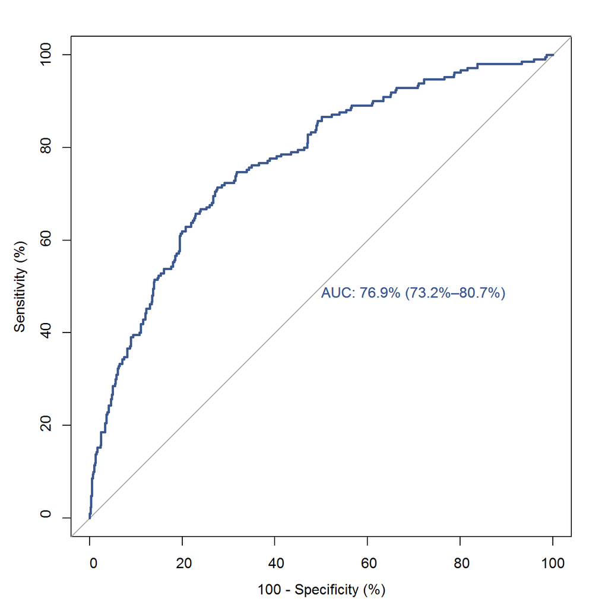

```r
complete_data_unimputed$LP1 <- predictrms(complete_Cox_primout, data= complete_data_unimputed)
complete_data_unimputed$prob.primout = 1-s0365.primout.unimputed^exp(complete_data_unimputed$LP1)

roc.primout.unimputed <-  roc(complete_data_unimputed$MIorAllcausedeath,
                              complete_data_unimputed$prob.primout,
                              auc.polygon = TRUE,
                              print.auc =TRUE,
                              ci = TRUE, percent = TRUE,
                              legacy.axis=TRUE)

plot.roc(roc.primout.unimputed, asp=NA,
         legacy.axes = TRUE,
         type="l",
         lwd = 2.5,
         col = "#3C588f",
         pch = 21,
         ci = TRUE,
         print.auc = TRUE,
         ylim = c(0,100))
```

### 4.1.2 Secondary outcome

We re-fit the model for the secondary outcome using the dataset where we have deleted all the rows that have missing values.

```r
complete_Cox_secout <- cph(Surv(timetoevent_cr, status==1)~ rcs(Age,c(48,71,81,91)) +
                                                            rcs(eGFR,c(31,65,96)) +
                                                            logTroponin + Anaemia +
                                                            MyocardialIschemia + PrevHFHospitalisation +
                                                            PrevDiabetes + PrevIHD +
                                                            rcs(HeartRate,c(65,100,151)),
                  data = complete_data_unimputed,
                  x = TRUE, y = TRUE, surv = TRUE, model = TRUE, time.inc = 365)

print(complete_Cox_secout)
```

```
## Cox Proportional Hazards Model
##
##  cph(formula = Surv(timetoevent_cr, status == 1) ~ rcs(Age, c(48,
##      71, 81, 91)) + rcs(eGFR, c(31, 65, 96)) + logTroponin + Anaemia +
##      MyocardialIschemia + PrevHFHospitalisation + PrevDiabetes +
##      PrevIHD + rcs(HeartRate, c(65, 100, 151)), data = complete_data_unimputed,
##      model = TRUE, x = TRUE, y = TRUE, surv = TRUE, time.inc = 365)
##
##                      Model Tests       Discrimination
##                                           Indexes
##  Obs       817    LR chi2     98.48    R2       0.137
##  Events    110    d.f.           13    Dxy      0.496
##  Center 0.4467    Pr(> chi2) 0.0000    g        1.021
##                   Score chi2 117.21    gr       2.776
##                   Pr(> chi2) 0.0000
##
##                            Coef    S.E.   Wald Z Pr(>|Z|)
##  Age                       -0.0056 0.0253 -0.22  0.8252
##  Age'                      -0.0070 0.0434 -0.16  0.8723
##  Age''                      0.4682 0.3063  1.53  0.1263
##  eGFR                      -0.0106 0.0085 -1.25  0.2106
##  eGFR'                      0.0089 0.0105  0.85  0.3979
##  logTroponin                0.1605 0.0521  3.08  0.0021
##  Anaemia=Yes                0.3344 0.2046  1.63  0.1021
##  MyocardialIschemia=Yes     0.0057 0.2050  0.03  0.9777
##  PrevHFHospitalisation=Yes  0.9282 0.2081  4.46  <0.0001
##  PrevDiabetes=Yes           0.4637 0.2444  1.90  0.0578
##  PrevIHD=Yes                0.2443 0.2231  1.10  0.2734
##  HeartRate                 -0.0008 0.0071 -0.11  0.9094
##  HeartRate'                -0.0078 0.0106 -0.74  0.4620
##
```

A comparison of the estimated coefficients:

```r
unimputed_sec <- complete_Cox_secout %>% tbl_regression(exponentiate=TRUE)
imputed_sec <- Cox_secout %>% tbl_regression(exponentiate=TRUE)

tbl_merge(tbls = list(imputed_sec, unimputed_sec),
          tab_spanner = c("**Imputed**", "**Unimputed**"))
```

| **Characteristic** | **Imputed** **HR**<sup>1</sup> | **Imputed** **95% CI**<sup>1</sup> | **Imputed** **p-value** | **Unimputed** **HR**<sup>1</sup> | **Unimputed** **95% CI**<sup>1</sup> | **Unimputed** **p-value** |
| --- | --- | --- | --- | --- | --- | --- |
| Age | 1.00 | 0.95, 1.04 | 0.8 | 0.99 | 0.95, 1.04 | 0.8 |
| Age' | 1.02 | 0.95, 1.09 | 0.6 | 0.99 | 0.91, 1.08 | 0.9 |
| Age'' | 1.17 | 0.72, 1.90 | 0.5 | 1.60 | 0.88, 2.91 | 0.13 |
| eGFR | 0.99 | 0.98, 1.00 | 0.11 | 0.99 | 0.97, 1.01 | 0.2 |
| eGFR' | 1.01 | 0.99, 1.03 | 0.4 | 1.01 | 0.99, 1.03 | 0.4 |
| logTroponin | 1.17 | 1.07, 1.27 | <0.001 | 1.17 | 1.06, 1.30 | 0.002 |
| Anaemia=Yes | 1.58 | 1.14, 2.20 | 0.006 | 1.40 | 0.94, 2.09 | 0.10 |
| MyocardialIschemia=Yes | 1.07 | 0.77, 1.48 | 0.7 | 1.01 | 0.67, 1.50 | >0.9 |
| PrevHFHospitalisation=Yes | 2.20 | 1.58, 3.07 | <0.001 | 2.53 | 1.68, 3.80 | <0.001 |
| PrevDiabetes=Yes | 1.43 | 0.95, 2.15 | 0.090 | 1.59 | 0.98, 2.57 | 0.058 |
| PrevIHD=Yes | 1.19 | 0.84, 1.69 | 0.3 | 1.28 | 0.82, 1.98 | 0.3 |
| HeartRate | 1.00 | 0.99, 1.01 | 0.8 | 1.00 | 0.99, 1.01 | >0.9 |
| HeartRate' | 0.99 | 0.98, 1.01 | 0.5 | 0.99 | 0.97, 1.01 | 0.5 |

<sup>*1*</sup> HR = Hazard Ratio, CI = Confidence Interval

Baseline survival function for secondary outcome model with non-imputed dataset:

```r
S0unimputed2 = exp(-basehaz(complete_Cox_secout)$hazard)
s0365.secout.unimputed <- S0unimputed2[length(S0unimputed2)]
s0365.secout.unimputed
```

```
## [1] 0.8912421
```

As before, we report AUROC as a measure of discrimination:

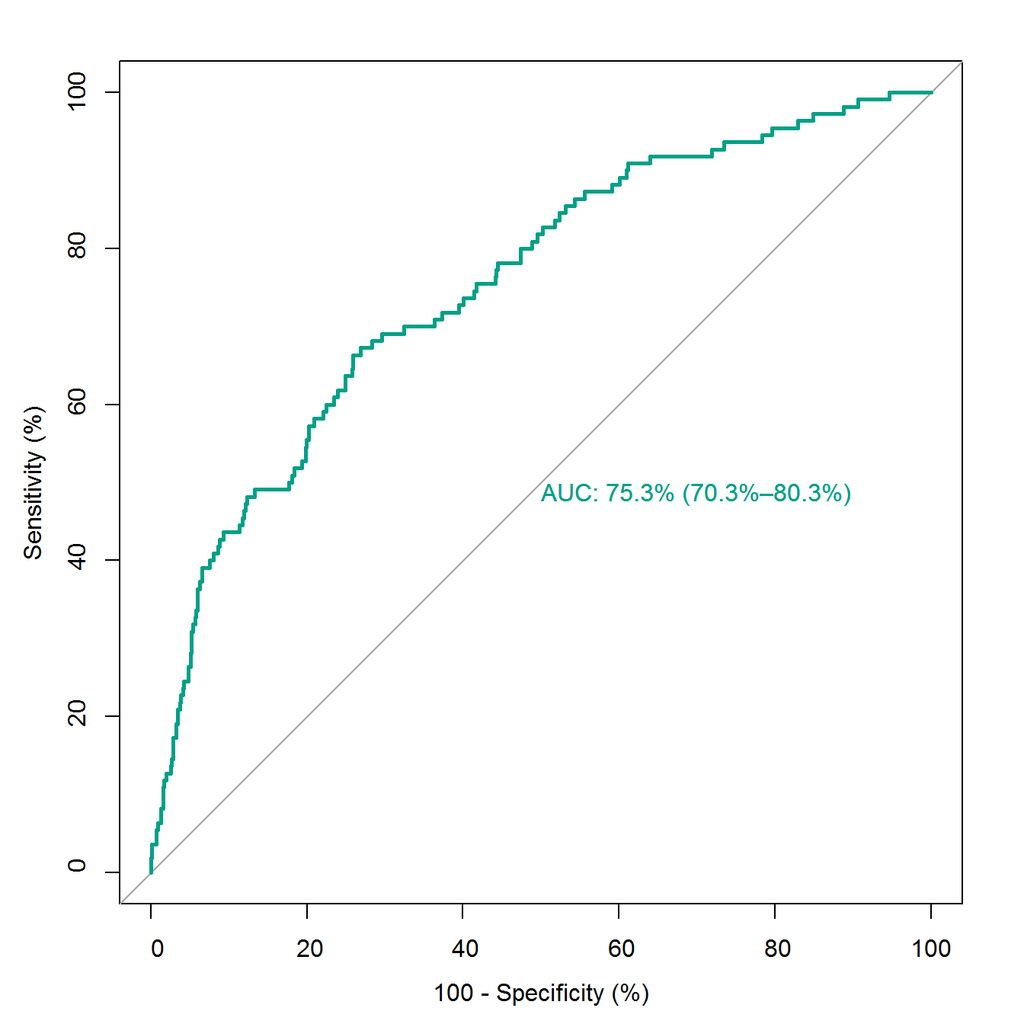

```r
complete_data_unimputed$LP2 <- predictrms(complete_Cox_secout, data= complete_data_unimputed)
complete_data_unimputed$prob.secout = 1-s0365.secout.unimputed^exp(complete_data_unimputed$LP2)

roc.secout.unimputed <-  roc(complete_data_unimputed$secondary_outcome,
                              complete_data_unimputed$prob.secout,
                              auc.polygon = TRUE,
                              print.auc =TRUE,
                              ci = TRUE, percent = TRUE,
                              legacy.axis=TRUE)

plot.roc(roc.secout.unimputed,
         asp = NA,
         legacy.axes = TRUE,
         type = "l",
         lwd = 2.5,
         col = "#00a087ff",
         pch = 21,
         ci = TRUE,
         print.auc = TRUE,
         ylim = c(0,100))
```

## 4.2 Sensitivity analyisis of 30-day events

In the following we investigate the effect of removing events that occurred during the first 30 days as our data contains a high amount of early events in hospital which are due to severe illness.

### 4.2.1 Primary outcome

```r
df_type2mi_30daysevents = data_TypeII_imputed_reduced %>%
  filter(data_TypeII_imputed_reduced$days_MIorALLCAUSE>30)


cox30days_prim = cph(Surv(days_MIorALLCAUSE, MIorAllcausedeath)~ rcs(Age,c(48,71,81,91)) +
                                                            rcs(eGFR,c(31,65,96)) +
                                                            logTroponin + Anaemia +
                                                            MyocardialIschemia + PrevHFHospitalisation +
                                                            PrevDiabetes + PrevIHD +
                                                            rcs(HeartRate,c(65,100,151)),
                  data = df_type2mi_30daysevents,
                  x = TRUE, y = TRUE, surv = TRUE, model = TRUE, time.inc = 365)
```

A comparison of the estimated coefficients:

```r
modelall <- Cox_primout %>% tbl_regression(exponentiate=TRUE)
sens30days<- cox30days_prim %>% tbl_regression(exponentiate=TRUE)

tbl_merge(tbls = list(modelall, sens30days),
          tab_spanner = c("**All events**", "**Without 30 days events**"))
```

| **Characteristic** | **All events** **HR**<sup>1</sup> | **All events** **95% CI**<sup>1</sup> | **All events** **p-value** | **Without 30 days events** **HR**<sup>1</sup> | **Without 30 days events** **95% CI**<sup>1</sup> | **Without 30 days events** **p-value** |
| --- | --- | --- | --- | --- | --- | --- |
| Age | 1.03 | 0.99, 1.07 | 0.14 | 1.03 | 0.98, 1.08 | 0.3 |
| Age' | 0.99 | 0.93, 1.05 | 0.7 | 1.00 | 0.93, 1.08 | >0.9 |
| Age'' | 1.26 | 0.86, 1.85 | 0.2 | 1.16 | 0.73, 1.85 | 0.5 |
| eGFR | 0.98 | 0.97, 0.99 | <0.001 | 0.99 | 0.98, 1.00 | 0.029 |
| eGFR' | 1.02 | 1.01, 1.03 | 0.003 | 1.01 | 1.00, 1.03 | 0.10 |
| logTroponin | 1.12 | 1.05, 1.19 | <0.001 | 1.07 | 0.99, 1.16 | 0.092 |
| Anaemia=Yes | 1.52 | 1.19, 1.94 | <0.001 | 1.41 | 1.06, 1.87 | 0.017 |
| MyocardialIschemia=Yes | 1.18 | 0.93, 1.50 | 0.2 | 1.21 | 0.92, 1.61 | 0.2 |
| PrevHFHospitalisation=Yes | 1.53 | 1.19, 1.96 | <0.001 | 1.43 | 1.07, 1.91 | 0.016 |
| PrevDiabetes=Yes | 1.36 | 0.99, 1.86 | 0.057 | 1.22 | 0.85, 1.76 | 0.3 |
| PrevIHD=Yes | 1.09 | 0.84, 1.41 | 0.5 | 1.60 | 1.18, 2.18 | 0.003 |
| HeartRate | 1.01 | 1.00, 1.02 | 0.2 | 1.00 | 0.99, 1.01 | >0.9 |
| HeartRate' | 0.98 | 0.97, 1.00 | 0.027 | 0.99 | 0.97, 1.00 | 0.2 |

<sup>*1*</sup> HR = Hazard Ratio, CI = Confidence Interval

```r
#make new s0365
S030days = exp(-basehaz(cox30days_prim)$hazard)
s0365.30days_prim = S030days[length(S030days)]


#LPs and probability
df_type2mi_30daysevents$LP30days_prim <- predictrms(cox30days_prim, data= df_type2mi_30daysevents)
df_type2mi_30daysevents$prob.primout = 1-s0365.30days_prim^exp(df_type2mi_30daysevents$LP30days_prim)

#roc
roc.30days_prim <-  roc(df_type2mi_30daysevents$MIorAllcausedeath,
                              df_type2mi_30daysevents$prob.primout,
                              auc.polygon = TRUE,
                              print.auc =TRUE,
                              ci = TRUE, percent = TRUE,
                              legacy.axis=TRUE)
```

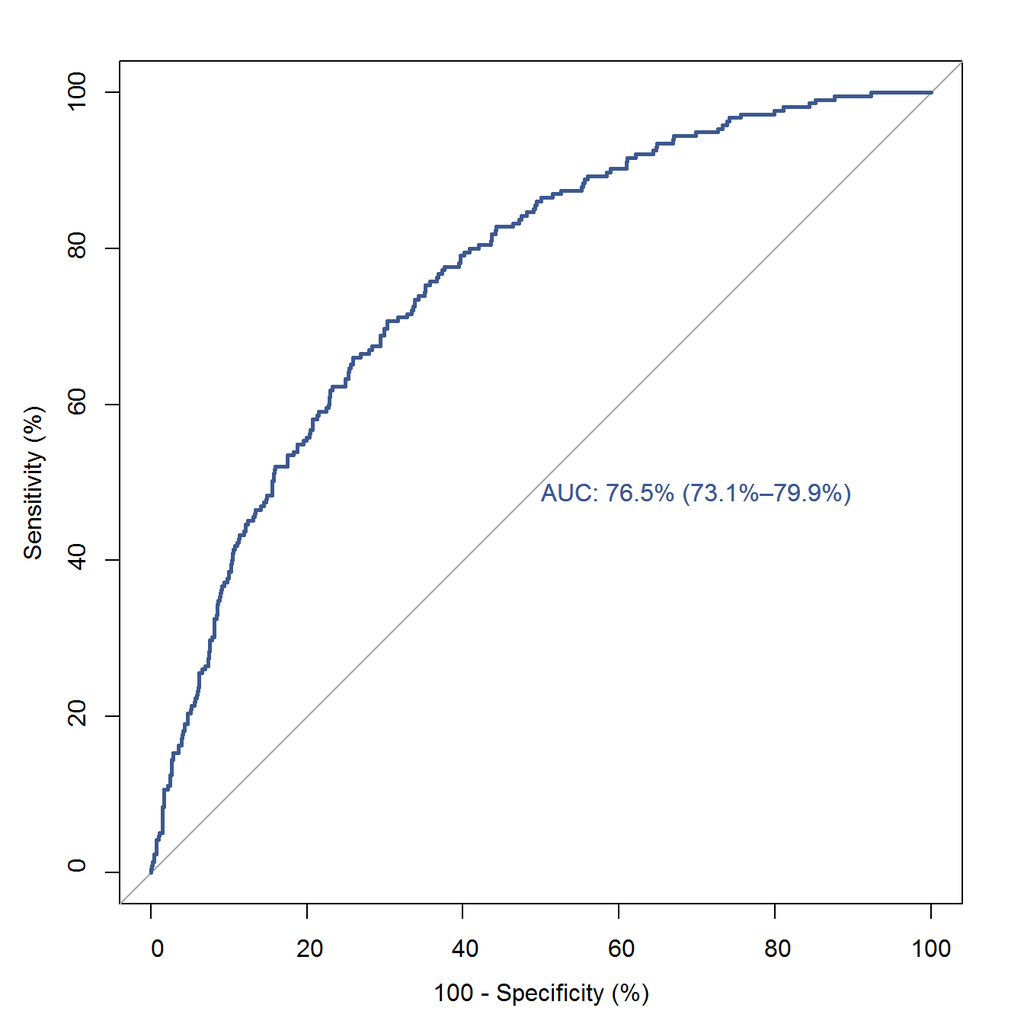

```r
plot.roc(roc.30days_prim, asp=NA,
         legacy.axes = TRUE,
         type="l",
         lwd = 2.5,
         col = "#3C588f",
         pch = 21,
         ci = TRUE,
         print.auc = TRUE,
         ylim = c(0,100))
```

### 4.2.2 Secondary outcome

The sensitivity analysis for the secondary outcome is also provided:

```r
df_type2mi_30daysevents = data_TypeII_imputed_reduced %>%
  filter(data_TypeII_imputed_reduced$timetoevent_cr>30)

cox30days_sec = cph(Surv(timetoevent_cr, status==1)~ rcs(Age,c(48,71,81,91)) +
                                                            rcs(eGFR,c(31,65,96)) +
                                                            logTroponin + Anaemia +
                                                            MyocardialIschemia + PrevHFHospitalisation +
                                                            PrevDiabetes + PrevIHD +
                                                            rcs(HeartRate,c(65,100,151)),
                  data = df_type2mi_30daysevents,
                  x = TRUE, y = TRUE, surv = TRUE, model = TRUE, time.inc = 365)


modelall.sec <- Cox_secout %>% tbl_regression(exponentiate=TRUE)
sens30days.sec<- cox30days_sec %>% tbl_regression(exponentiate=TRUE)

tbl_merge(tbls = list(modelall.sec, sens30days.sec),
          tab_spanner = c("**All events**", "**Without 30 days events**"))
```

| **Characteristic** | **All events** **HR**<sup>1</sup> | **All events** **95% CI**<sup>1</sup> | **All events** **p-value** | **Without 30 days events** **HR**<sup>1</sup> | **Without 30 days events** **95% CI**<sup>1</sup> | **Without 30 days events** **p-value** |
| --- | --- | --- | --- | --- | --- | --- |
| Age | 1.00 | 0.95, 1.04 | 0.8 | 1.00 | 0.95, 1.05 | >0.9 |
| Age' | 1.02 | 0.95, 1.09 | 0.6 | 1.01 | 0.92, 1.09 | 0.9 |
| Age'' | 1.17 | 0.72, 1.90 | 0.5 | 1.28 | 0.73, 2.24 | 0.4 |
| eGFR | 0.99 | 0.98, 1.00 | 0.11 | 1.00 | 0.98, 1.01 | 0.7 |
| eGFR' | 1.01 | 0.99, 1.03 | 0.4 | 1.00 | 0.98, 1.02 | >0.9 |
| logTroponin | 1.17 | 1.07, 1.27 | <0.001 | 1.15 | 1.04, 1.27 | 0.006 |
| Anaemia=Yes | 1.58 | 1.14, 2.20 | 0.006 | 1.45 | 1.00, 2.10 | 0.052 |
| MyocardialIschemia=Yes | 1.07 | 0.77, 1.48 | 0.7 | 1.09 | 0.75, 1.59 | 0.6 |
| PrevHFHospitalisation=Yes | 2.20 | 1.58, 3.07 | <0.001 | 1.69 | 1.16, 2.48 | 0.006 |
| PrevDiabetes=Yes | 1.43 | 0.95, 2.15 | 0.090 | 1.19 | 0.73, 1.92 | 0.5 |
| PrevIHD=Yes | 1.19 | 0.84, 1.69 | 0.3 | 1.82 | 1.21, 2.76 | 0.004 |
| HeartRate | 1.00 | 0.99, 1.01 | 0.8 | 0.99 | 0.98, 1.01 | 0.3 |
| HeartRate' | 0.99 | 0.98, 1.01 | 0.5 | 1.00 | 0.98, 1.02 | >0.9 |

<sup>*1*</sup> HR = Hazard Ratio, CI = Confidence Interval

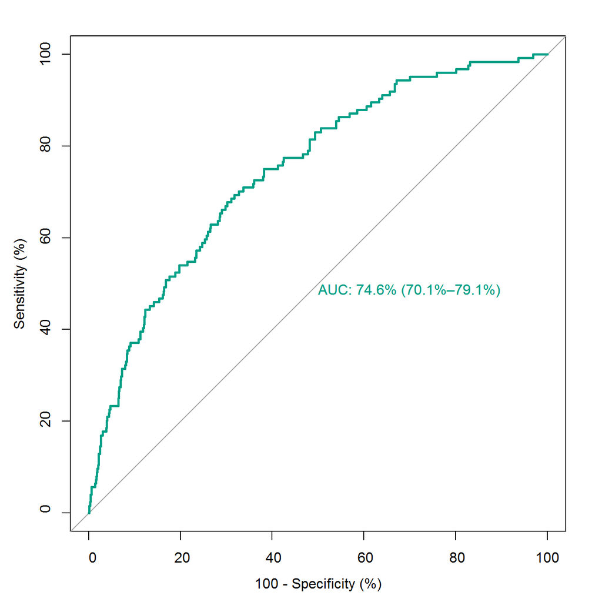

```r
#make new s0365
S030days = exp(-basehaz(cox30days_sec)$hazard)
s0365.30days_sec = S030days[length(S030days)]


#LPs and probability
df_type2mi_30daysevents$LP30days_sec <- predictrms(cox30days_sec, data= df_type2mi_30daysevents)
df_type2mi_30daysevents$prob.secout = 1-s0365.30days_sec^exp(df_type2mi_30daysevents$LP30days_sec)

#roc
roc.30days <-  roc(df_type2mi_30daysevents$secondary_outcome,
                              df_type2mi_30daysevents$prob.secout,
                              auc.polygon = TRUE,
                              print.auc =TRUE,
                              ci = TRUE, percent = TRUE,
                              legacy.axis=TRUE)

plot.roc(roc.30days, asp=NA,
         legacy.axes = TRUE,
         type="l",
         lwd = 2.5,
         col = "#00a087ff",
         pch = 21,
         ci = TRUE,
         print.auc = TRUE,
         ylim = c(0,100))
```